# fiddler crab, claw evolution

Alexandre V. Palaoro

Last compiled on 04/09/2025

```r
knitr::opts_chunk$set(echo = TRUE, fig.width = 6, fig.height = 6)

library(ape)
library(phytools)
library(geiger)
library(tidyverse)
library(bbmle)
library(mvMORPH)
library(vioplot)
library(ellipse)
library(phylolm)
library(ratematrix)
library(viridis)
library(scales)
library(vioplot)
library(performance)
library(corncob)
library(lattice)
library(latticeExtra)
library(RColorBrewer)
library(sp)
library(pander)
library(scatterplot3d)
```

```r
#### Along with all the packages, we are also an analysis provided in the following paper:

# Slater, G. J., & Friscia, A. R. (2019). Hierarchy in adaptive radiation: a case study using the Carnivora (Mammalia). Evolution, 73(3), 524-539.

#### I will explain more about it below.

source("D:/OneDrive/Orientados/Mestrado - Jonatas/Mestrado/new_paper/claw.evol/code/RateMatrixFunctions.R")
```

## Loading data

Setting up the code and loading the phylogeny and data. Since we are using the datasheet that contains the measurements from all individuals, we are loading it and summarizing it by species. That way we can run the comparative methods.

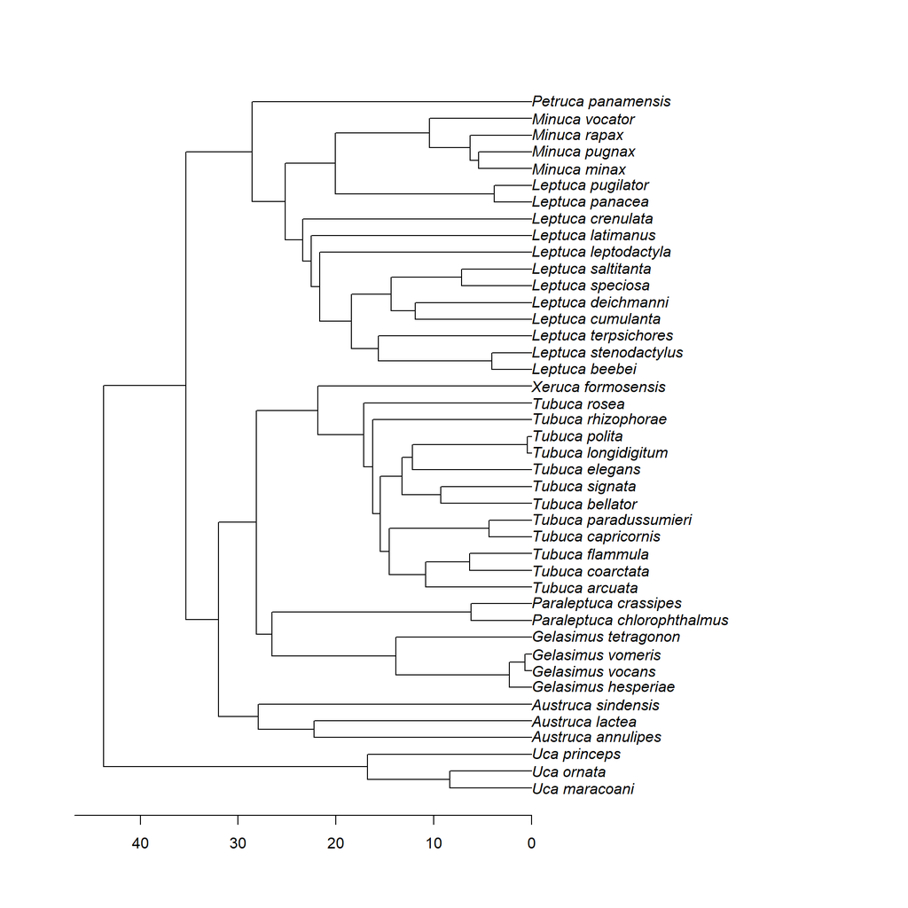

```r
#### Loading tree ####

phy = read.nexus("D:/OneDrive/Orientados/Mestrado - Jonatas/Mestrado/new_paper/claw.evol/data/Fiddler_complete.nex")

plot(phy); axisPhylo()
```

```r
#### Loading raw data ####

uca = read.csv("D:/OneDrive/Orientados/Mestrado - Jonatas/Mestrado/new_paper/claw.evol/data/def_linear_01-08-25.csv" , h = T, sep = ';')

#### Summarizing data ####
uca$prop.claw = uca$claw_size / uca$carapace
uca$prop.polex = uca$polex / uca$carapace
uca$prop.manus = uca$manus / uca$carapace
uca$prop.inlever = uca$in.lever / uca$carapace
uca$prop.out1 = uca$out.lever1 / uca$carapace
uca$prop.out2 = uca$out.lever2 / uca$carapace

uca.short = uca %>% group_by(sp) %>%
  summarise(
    mean.carapace=mean( carapace , na.rm=T),
    mean.claw = mean(claw_size, na.rm=T),
    mean.tip=mean(tip_adv, na.rm=T),
    mean.tub=mean(tub_adv, na.rm=T),
    mean.polex=mean(polex, na.rm=T),
    mean.manus=mean(manus, na.rm=T),
    mean.out.tub = mean(out.lever1, na.rm=T),
    mean.dactyl = mean(out.lever2, na.rm = T),
    mean.inl = mean(in.lever, na.rm = T),
    sd.carapace = sd(carapace, na.rm=T),
    sd.claw = sd(prop.claw, na.rm=T),
    sd.tip = sd(tip_adv, na.rm=T),
    sd.tub = sd(tub_adv, na.rm=T),
    sd.polex = sd(prop.polex, na.rm=T),
    sd.manus = sd(prop.manus, na.rm=T),
    sd.out.tub = sd(prop.out1, na.rm=T),
    sd.dactyl = sd(prop.out2, na.rm = T),
    prop.inlever = mean( prop.inlever ),
    prop.out1 = mean( prop.out1 , na.rm = T ),
    prop.out2 = mean( prop.out2 , na.rm = T),
    prop.manus = mean( prop.manus , na.rm = T ),
    prop.polex = mean( prop.polex , na.rm = T ),
    prop.claw = mean( prop.claw , na.rm = T ),


    )

uca.short = as.data.frame(uca.short)

rownames(uca.short) = uca.short$sp

name.check(phy, uca.short)
```

```
## [1] "OK"
```

```r
#### Loading mating strategies ####

uca.mate = read.csv("data/def_mating_short.csv" , h = T, sep = ';')
uca.mate = uca.mate %>% arrange (sp)

uca.short$mating = uca.mate$mating
```

## PGLS

Our first series of tests regard claw evolutionary allometry and changes in the biomechanical relationships within components of the claw. To do this, we performed four PGLS regressions you can see below.

### Claw evolutionary allometry

```r
# I saved the results in RDS because I bootstraped the model. It saves time in the long run...
claw1_BM = readRDS("D:/OneDrive/Orientados/Mestrado - Jonatas/Mestrado/new_paper/claw.evol/data/claw1_BM.rds")
claw1_OUf = readRDS("D:/OneDrive/Orientados/Mestrado - Jonatas/Mestrado/new_paper/claw.evol/data/claw1_OUf.rds")
claw1_OUr = readRDS("D:/OneDrive/Orientados/Mestrado - Jonatas/Mestrado/new_paper/claw.evol/data/claw1_OUr.rds")


### The models are below

#claw1_BM = phylolm(log(mean.claw) ~ mating * log(mean.carapace), boot = 1000,
#            data=uca.short, phy=phy, model='BM', measurement_error=T)

#claw1_OUf = phylolm(log(mean.claw) ~ mating * log(mean.carapace), boot = 1000,
#                data=uca.short, phy=phy, model='OUfixedRoot', measurement_error=T)

#claw1_OUr =  phylolm(log(mean.claw) ~ mating * log(mean.carapace), boot = 1000,
#                data=uca.short, phy=phy, model='OUrandomRoot', measurement_error=T,
#                upper.bound = 300)

###

compare_performance(claw1_BM, claw1_OUf, claw1_OUr)
```

```
## Some of the nested models seem to be identical
```

```
## # Comparison of Model Performance Indices
##
## Name      |   Model | AIC (weights) | BIC (weights) |    R2 | R2 (adj.) |  RMSE | Sigma
## ---------------------------------------------------------------------------------------
## claw1_BM  | phylolm | -45.6 (0.576) | -35.1 (0.764) | 0.935 |     0.930 | 0.122 | 0.132
## claw1_OUf | phylolm | -43.6 (0.212) | -31.4 (0.118) | 0.935 |     0.930 | 0.122 | 0.134
## claw1_OUr | phylolm | -43.6 (0.212) | -31.4 (0.118) | 0.935 |     0.930 | 0.122 | 0.134
```

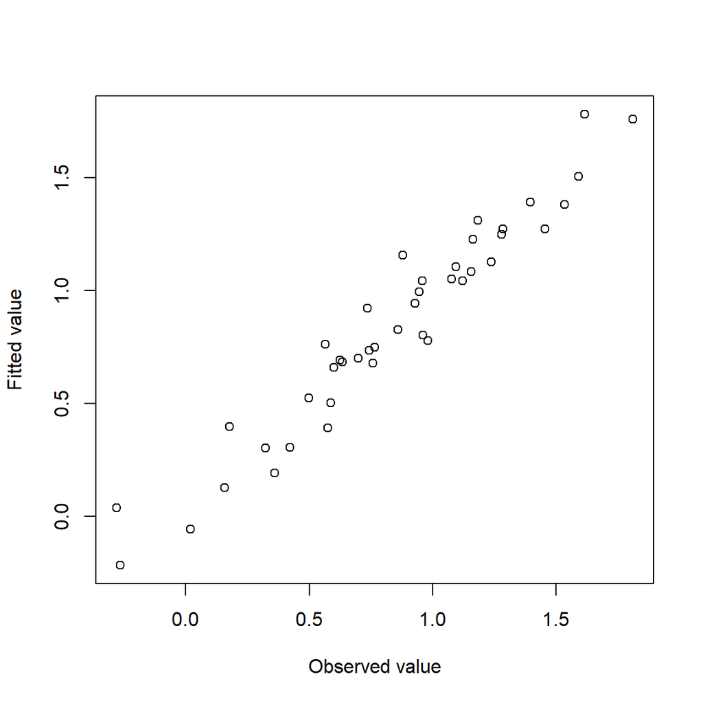

```r
## BM was chosen because it has the lowest AIC value

plot(claw1_BM)
```

```r
summary(claw1_BM)
```

```
##
## Call:
## phylolm(formula = log(mean.claw) ~ mating * log(mean.carapace),
##     data = uca.short, phy = phy, model = "BM", measurement_error = T,
##     boot = 1000)
##
##    AIC logLik
## -45.56  28.78
##
## Raw residuals:
##      Min       1Q   Median       3Q      Max
## -0.31614 -0.05784  0.01391  0.07914  0.20025
##
## Mean tip height: 43.73622
## Parameter estimate(s) using ML:
## sigma2: 3.655714e-12
## sigma2_error: 0.01486954
##
## Coefficients:
##                                   Estimate    StdErr   t.value lowerbootCI
## (Intercept)                       0.363822  0.032211 11.294786    0.304496
## matingsurface                    -0.038549  0.081149 -0.475035   -0.188809
## log(mean.carapace)                1.087321  0.053568 20.298058    0.985995
## matingsurface:log(mean.carapace) -0.015426  0.124720 -0.123684   -0.227269
##                                  upperbootCI   p.value
## (Intercept)                           0.4205 1.042e-13 ***
## matingsurface                         0.1005    0.6375
## log(mean.carapace)                    1.1804 < 2.2e-16 ***
## matingsurface:log(mean.carapace)      0.2101    0.9022
## ---
## Signif. codes:  0 '***' 0.001 '**' 0.01 '*' 0.05 '.' 0.1 ' ' 1
##
## R-squared: 0.9353    Adjusted R-squared: 0.9301
##
## sigma2: 3.655714e-12
##       bootstrap mean: 3.311873e-12 (on raw scale)
##                       3.21656e-12 (on log scale, then back transformed)
##       bootstrap 95% CI: (1.959919e-12,4.988668e-12)
##
## sigma2_error: 0.01486954
##       bootstrap mean: 0.01347097 (on raw scale)
##                       0.01308329 (on log scale, then back transformed)
##       bootstrap 95% CI: (0.007971929,0.0202913)
##
## Parametric bootstrap results based on 1000 fitted replicates
```

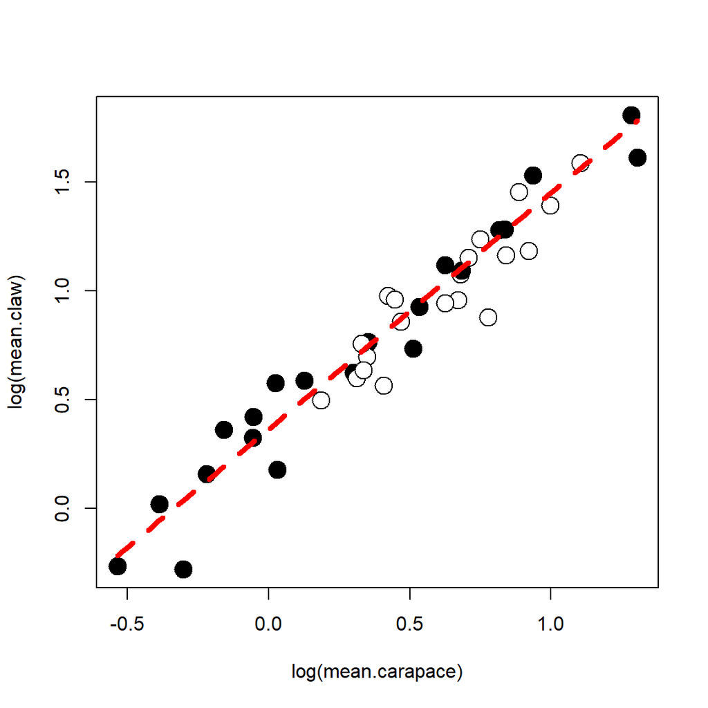

```r
plot( log(mean.claw) ~ log(mean.carapace), data = uca.short,
      cex = 2 , pch = 21, bg = c("black","white")[as.numeric(as.factor(uca.short$mating))])

curve( coef(claw1_BM)[1] + (coef(claw1_BM)[3] * x), add = T,
       col = 'red', lty = 2, lwd = 4)
```

### Claw lever versus claw strength

```r
###### CLAW DACTYL LENGTH VERSUS CLAW MANUS LENGTH - PROPORTIONAL #####

claw5_BM = readRDS("D:/OneDrive/Orientados/Mestrado - Jonatas/Mestrado/new_paper/claw.evol/data/claw5_BM.rds")
claw5_OUf = readRDS("D:/OneDrive/Orientados/Mestrado - Jonatas/Mestrado/new_paper/claw.evol/data/claw5_OUf.rds")
claw5_OUr = readRDS("D:/OneDrive/Orientados/Mestrado - Jonatas/Mestrado/new_paper/claw.evol/data/claw5_OUr.rds")

### The models are below
#claw5_BM = phylolm(prop.out2 ~ prop.manus * mating, data = uca.short, boot = 1000,
#                   phy = phy, model = "BM", measurement_error = T)

#claw5_OUf = phylolm(prop.out2 ~ prop.manus * mating, data = uca.short, boot = 1000,
#                    phy = phy, model = "OUfixedRoot", measurement_error = T)

#claw5_OUr = phylolm(prop.out2 ~ prop.manus * mating, data = uca.short, boot = 1000,
#                    phy = phy, model = "OUrandomRoot", measurement_error = T,
#                    upper.bound = 20)

###

compare_performance(claw5_BM, claw5_OUf, claw5_OUr)
```

```
## Some of the nested models seem to be identical
```

```
## # Comparison of Model Performance Indices
##
## Name      |   Model | AIC (weights) | BIC (weights) |    R2 | R2 (adj.) |  RMSE | Sigma
## ---------------------------------------------------------------------------------------
## claw5_BM  | phylolm | -11.0 (0.576) |  -0.6 (0.764) | 0.142 |     0.074 | 0.184 | 0.199
## claw5_OUf | phylolm |  -9.0 (0.212) |   3.2 (0.118) | 0.142 |     0.074 | 0.184 | 0.202
## claw5_OUr | phylolm |  -9.0 (0.212) |   3.2 (0.118) | 0.142 |     0.074 | 0.184 | 0.202
```

```r
## Once again, BM was the model with the lowest AIC

summary(claw5_BM)
```

```
##
## Call:
## phylolm(formula = prop.out2 ~ prop.manus * mating, data = uca.short,
##     phy = phy, model = "BM", measurement_error = T, boot = 1000)
##
##    AIC logLik
##  -11.0   11.5
##
## Raw residuals:
##      Min       1Q   Median       3Q      Max
## -0.53188 -0.10228  0.01124  0.11870  0.33955
##
## Mean tip height: 43.73622
## Parameter estimate(s) using ML:
## sigma2: 1.274756e-12
## sigma2_error: 0.03386214
##
## Coefficients:
##                          Estimate   StdErr  t.value lowerbootCI upperbootCI
## (Intercept)               0.92815  0.37681  2.46315     0.24325      1.6625
## prop.manus                0.10279  0.55535  0.18510    -0.96713      1.0667
## matingsurface            -1.02212  0.67305 -1.51865    -2.30124      0.1711
## prop.manus:matingsurface  1.37548  1.00136  1.37361    -0.37219      3.2802
##                          p.value
## (Intercept)              0.01842 *
## prop.manus               0.85414
## matingsurface            0.13713
## prop.manus:matingsurface 0.17761
## ---
## Signif. codes:  0 '***' 0.001 '**' 0.01 '*' 0.05 '.' 0.1 ' ' 1
##
## R-squared: 0.1417    Adjusted R-squared: 0.07389
##
## sigma2: 1.274756e-12
##       bootstrap mean: 1.139573e-12 (on raw scale)
##                       1.106907e-12 (on log scale, then back transformed)
##       bootstrap 95% CI: (6.710812e-13,1.721439e-12)
##
## sigma2_error: 0.03386214
##       bootstrap mean: 0.03027119 (on raw scale)
##                       0.02940346 (on log scale, then back transformed)
##       bootstrap 95% CI: (0.01782636,0.04572766)
##
## Parametric bootstrap results based on 1000 fitted replicates
```

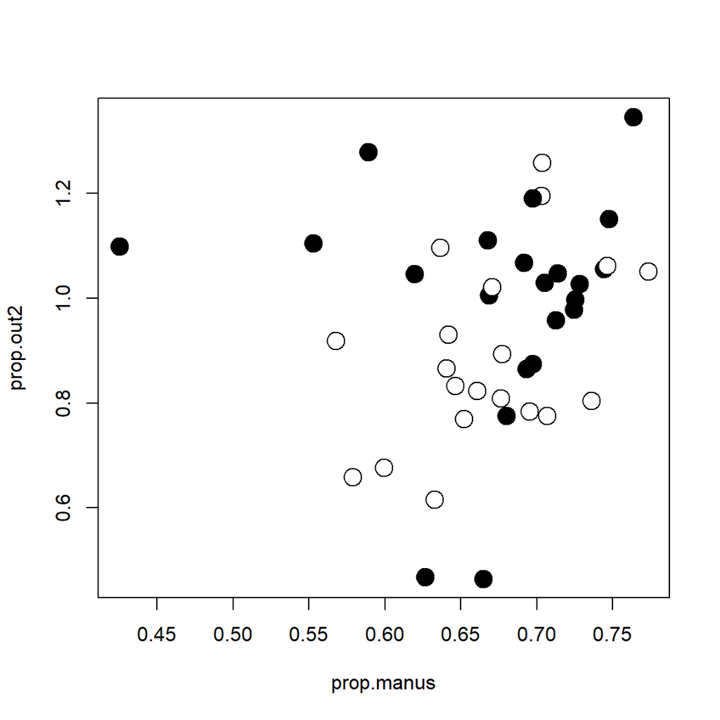

```r
#Filled dots = burrow mating system; white dots = surface mating system

plot( prop.out2 ~ prop.manus, data = uca.short,
      cex = 2 , pch = 21, bg = c("black","white")[as.numeric(as.factor(uca.short$mating))])
```

### Mechanical advantage versus relative claw muscle

Given that not all species have tubercles on their dactyl (the movable finger), we performed one test of the mechanical advantage calculated at the tip, and another test where mechanical advantage was calculated at the tubercule. The second test excluded 9 species our sample.

```r
#### Mechanical advantage at the tip ####

claw6_BM = readRDS("D:/OneDrive/Orientados/Mestrado - Jonatas/Mestrado/new_paper/claw.evol/data/claw6_BM.rds")
claw6_OUf = readRDS("D:/OneDrive/Orientados/Mestrado - Jonatas/Mestrado/new_paper/claw.evol/data/claw6_OUf.rds")
claw6_OUr = readRDS("D:/OneDrive/Orientados/Mestrado - Jonatas/Mestrado/new_paper/claw.evol/data/claw6_OUr.rds")

### The models are below
#claw6_BM = phylolm(mean.tip ~ prop.manus * mating, data = uca.short, boot = 1000,
#                   phy = phy, model = "BM", measurement_error = T)

#claw6_OUf = phylolm(mean.tip ~ prop.manus * mating, data = uca.short, boot = 1000,
#                    phy = phy, model = "OUfixedRoot", measurement_error = T)

#claw6_OUr = phylolm(mean.tip ~ prop.manus * mating, data = uca.short, boot = 1000,
#                    phy = phy, model = "OUrandomRoot", measurement_error = T,
#                    upper.bound = 10^3)

compare_performance(claw6_BM, claw6_OUf, claw6_OUr)
```

```
## Some of the nested models seem to be identical
```

```
## # Comparison of Model Performance Indices
##
## Name      |   Model |  AIC (weights) |  BIC (weights) |    R2 | R2 (adj.)
## -------------------------------------------------------------------------
## claw6_BM  | phylolm | -132.8 (0.576) | -122.3 (0.764) | 0.158 |     0.092
## claw6_OUf | phylolm | -130.8 (0.212) | -118.6 (0.118) | 0.158 |     0.092
## claw6_OUr | phylolm | -130.8 (0.212) | -118.6 (0.118) | 0.158 |     0.092
##
## Name      |  RMSE | Sigma
## -------------------------
## claw6_BM  | 0.043 | 0.047
## claw6_OUf | 0.043 | 0.047
## claw6_OUr | 0.043 | 0.047
```

```r
summary(claw6_BM)
```

```
##
## Call:
## phylolm(formula = mean.tip ~ prop.manus * mating, data = uca.short,
##     phy = phy, model = "BM", measurement_error = T, boot = 1000)
##
##     AIC  logLik
## -132.75   72.38
##
## Raw residuals:
##       Min        1Q    Median        3Q       Max
## -0.057570 -0.034600 -0.003158  0.023474  0.147086
##
## Mean tip height: 43.73622
## Parameter estimate(s) using ML:
## sigma2: 6.161093e-13
## sigma2_error: 0.001865175
##
## Coefficients:
##                            Estimate     StdErr    t.value lowerbootCI
## (Intercept)               0.0493594  0.0884361  0.5581358  -0.1037900
## prop.manus                0.2519264  0.1303374  1.9328789   0.0066344
## matingsurface             0.2672171  0.1579601  1.6916751  -0.0296080
## prop.manus:matingsurface -0.3607236  0.2350126 -1.5349118  -0.8429956
##                          upperbootCI p.value
## (Intercept)                   0.2154 0.58003
## prop.manus                    0.4800 0.06073 .
## matingsurface                 0.5959 0.09889 .
## prop.manus:matingsurface      0.0732 0.13309
## ---
## Signif. codes:  0 '***' 0.001 '**' 0.01 '*' 0.05 '.' 0.1 ' ' 1
##
## R-squared: 0.1583    Adjusted R-squared: 0.09189
##
## sigma2: 6.161093e-13
##       bootstrap mean: 5.580773e-13 (on raw scale)
##                       5.435218e-13 (on log scale, then back transformed)
##       bootstrap 95% CI: (3.365147e-13,8.343757e-13)
##
## sigma2_error: 0.001865175
##       bootstrap mean: 0.001689493 (on raw scale)
##                       0.001645428 (on log scale, then back transformed)
##       bootstrap 95% CI: (0.001018746,0.002525943)
##
## Parametric bootstrap results based on 1000 fitted replicates
```

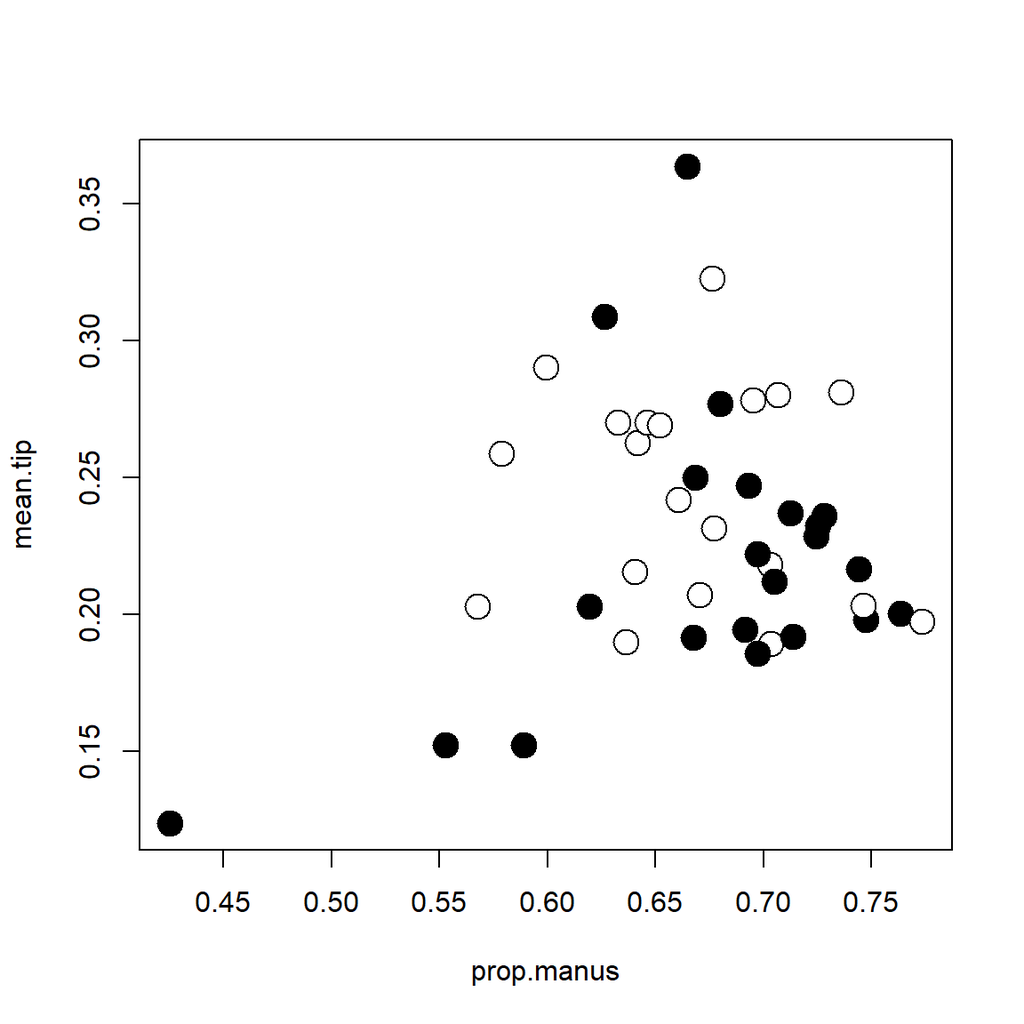

```r
plot( mean.tip ~ prop.manus, data = uca.short,
      cex = 2 , pch = 21,
      bg = c("black","white")[as.numeric(as.factor(uca.short$mating))])
```

```r
#### Mechanical advantage at the tubercle ####

claw7_BM = readRDS("D:/OneDrive/Orientados/Mestrado - Jonatas/Mestrado/new_paper/claw.evol/data/claw7_BM.rds")
claw7_OUf = readRDS("D:/OneDrive/Orientados/Mestrado - Jonatas/Mestrado/new_paper/claw.evol/data/claw7_OUf.rds")
claw7_OUr = readRDS("D:/OneDrive/Orientados/Mestrado - Jonatas/Mestrado/new_paper/claw.evol/data/claw7_OUr.rds")

### The models are below
#claw7_BM = phylolm(mean.tub ~ prop.manus * mating, data = uca.short, boot = 1000,
#                   phy = phy, model = "BM", measurement_error = T)

#claw7_OUf = phylolm(mean.tub ~ prop.manus * mating, data = uca.short,  boot = 1000,
#                    phy = phy, model = "OUfixedRoot", measurement_error = T)

#claw7_OUr = phylolm(mean.tub ~ prop.manus * mating, data = uca.short, boot = 10,
#                    phy = phy, model = "OUrandomRoot", measurement_error = T)
###

compare_performance(claw7_BM, claw7_OUf, claw7_OUr)
```

```
## Some of the nested models seem to be identical
```

```
## # Comparison of Model Performance Indices
##
## Name      |   Model | AIC (weights) | BIC (weights) |    R2 | R2 (adj.) |  RMSE | Sigma
## ---------------------------------------------------------------------------------------
## claw7_BM  | phylolm | -40.6 (0.560) | -31.6 (0.729) | 0.058 |    -0.039 | 0.123 | 0.136
## claw7_OUf | phylolm | -38.9 (0.244) | -28.5 (0.150) | 0.235 |     0.155 | 0.123 | 0.139
## claw7_OUr | phylolm | -38.5 (0.196) | -28.0 (0.121) | 0.220 |     0.139 | 0.123 | 0.139
```

```r
## Even though the OU fixed root and BM are tied, BM is a much simpler model

summary(claw7_BM)
```

```
##
## Call:
## phylolm(formula = mean.tub ~ prop.manus * mating, data = uca.short,
##     phy = phy, model = "BM", measurement_error = T, boot = 1000)
##
##    AIC logLik
## -40.61  26.31
##
## Raw residuals:
##      Min       1Q   Median       3Q      Max
## -0.21477 -0.08325 -0.00404  0.03176  0.36345
##
## Mean tip height: 43.73622
## Parameter estimate(s) using ML:
## sigma2: 0.0004193487
## sigma2_error: 0.002540626
##
## Coefficients:
##                           Estimate    StdErr   t.value lowerbootCI upperbootCI
## (Intercept)               0.383750  0.302502  1.268586   -0.161861      0.9442
## prop.manus                0.295747  0.455834  0.648805   -0.518146      1.1240
## matingsurface             0.090616  0.384325  0.235781   -0.613169      0.7630
## prop.manus:matingsurface -0.247829  0.594060 -0.417178   -1.265325      0.8328
##                          p.value
## (Intercept)               0.2147
## prop.manus                0.5216
## matingsurface             0.8153
## prop.manus:matingsurface  0.6796
##
## R-squared: 0.05819   Adjusted R-squared: -0.03924
##
## sigma2: 0.0004193487
##       bootstrap mean: 0.0003664497 (on raw scale)
##                       0.0003535978 (on log scale, then back transformed)
##       bootstrap 95% CI: (0.0002037418,0.0005765114)
##
## sigma2_error: 0.002540626
##       bootstrap mean: 0.002220137 (on raw scale)
##                       0.002142274 (on log scale, then back transformed)
##       bootstrap 95% CI: (0.001234371,0.003492797)
##
## Parametric bootstrap results based on 1000 fitted replicates
```

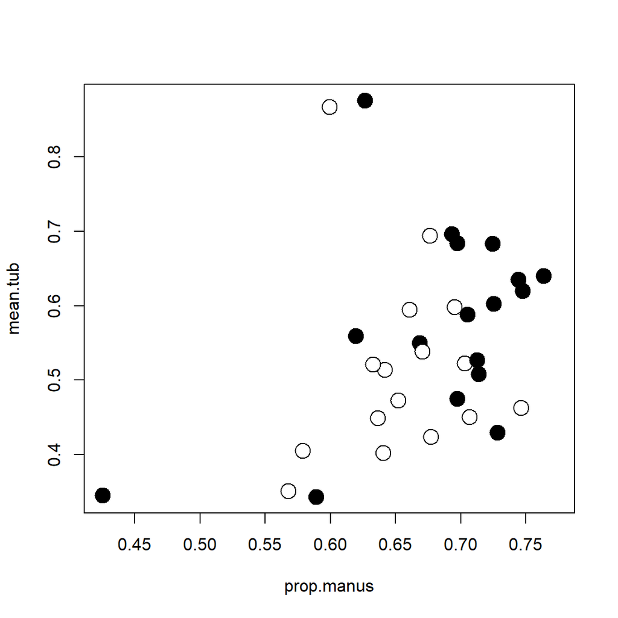

```r
plot( mean.tub ~ prop.manus, data = uca.short,
      cex = 2 , pch = 21, bg = c("black","white")[as.numeric(as.factor(uca.short$mating))])
```

### PGLS graphs

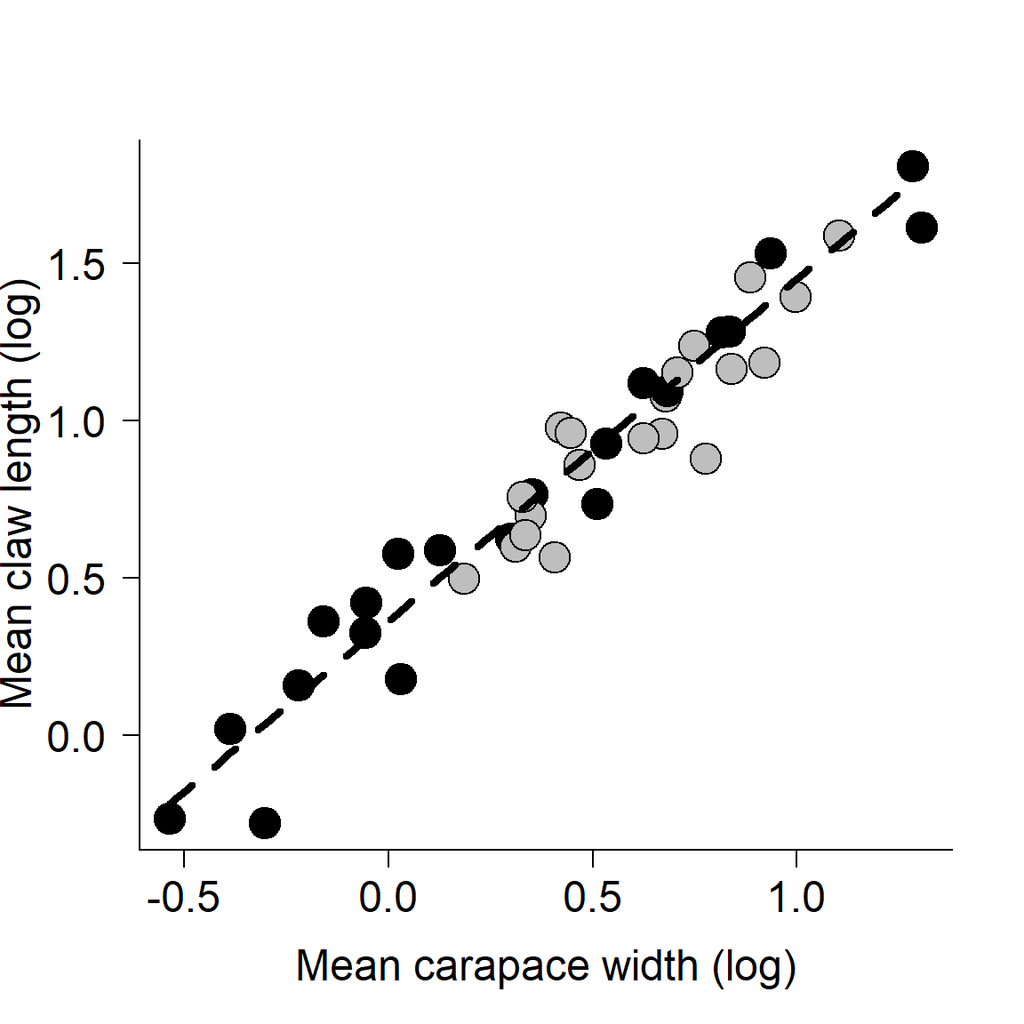

```r
### PHYLO REGRESSION GRAPHS ####

## Evolutionary allometry

plot( log(mean.claw) ~ log(mean.carapace), data = uca.short,
      cex = 2.5 , pch = 21, bg = c("black","grey")[as.numeric(as.factor(uca.short$mating))],
      las = 1, cex.axis = 1.5, cex.lab = 1.5,
      bty = 'l',
      ylab = "Mean claw length (log)",
      xlab = "Mean carapace width (log)")

curve( coef(claw1_BM)[1] + (coef(claw1_BM)[3] * x), add = T,
       col = 'black', lty = 2, lwd = 4)
```

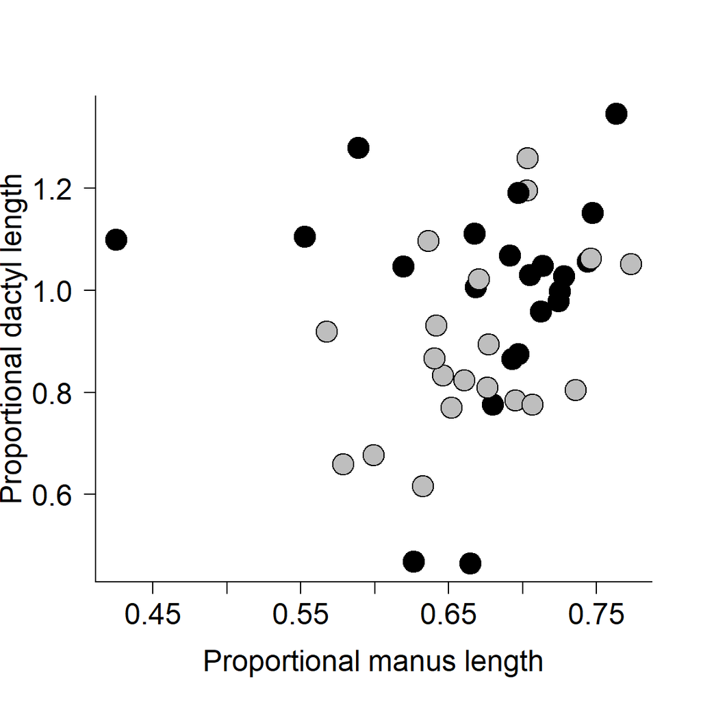

```r
## Dactyl and manus

plot( prop.out2 ~ prop.manus, data = uca.short,
      cex = 2.5 , pch = 21, bg = c("black","grey")[as.numeric(as.factor(uca.short$mating))],
      las = 1, cex.axis = 1.5, cex.lab = 1.5,
      bty = 'l',
      ylab = "Proportional dactyl length",
      xlab = "Proportional manus length")
```

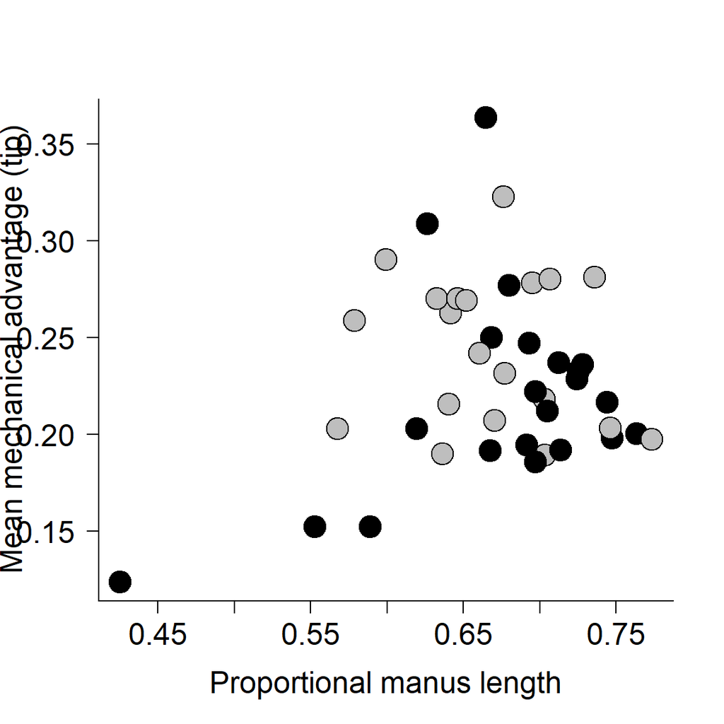

```r
### Mech Adv at the tip

plot( mean.tip ~ prop.manus, data = uca.short,
      cex = 2.5 , pch = 21, bg = c("black","grey")[as.numeric(as.factor(uca.short$mating))],
      las = 1, cex.axis = 1.5, cex.lab = 1.5,
      bty = 'l',
      ylab = "Mean mechanical advantage (tip)",
      xlab = "Proportional manus length")
```

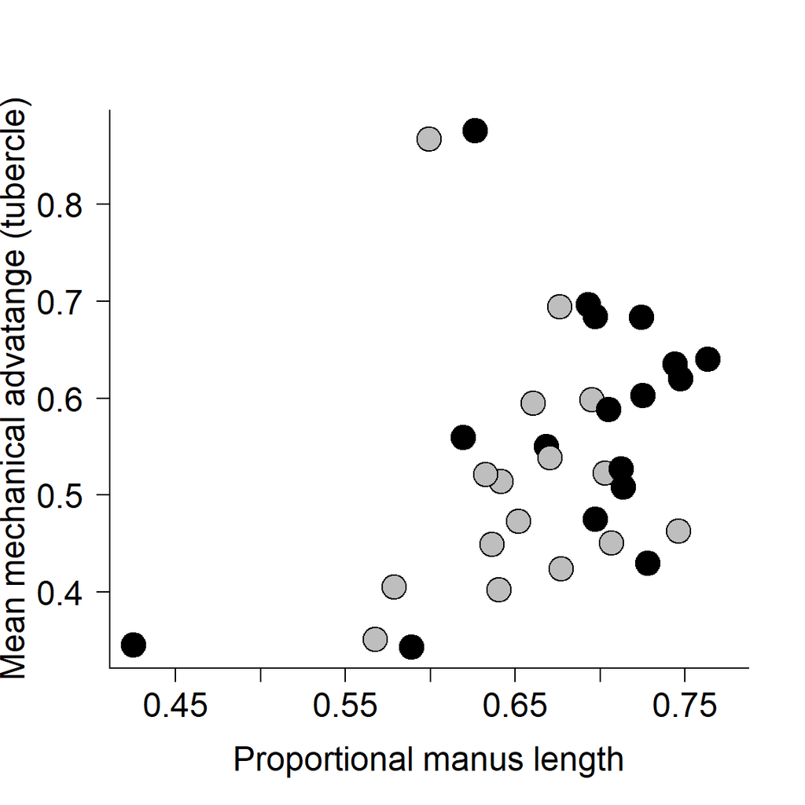

```r
### Mech Adv at the tub

plot( mean.tub ~ prop.manus, data = uca.short,
      cex = 2.5 , pch = 21, bg = c("black","grey")[as.numeric(as.factor(uca.short$mating))],
      las = 1, cex.axis = 1.5, cex.lab = 1.5,
      bty = 'l',
      ylab = "Mean mechanical advatange (tubercle)",
      xlab = "Proportional manus length")
```

## Intraspecific variation

Since we had measures of intraspecific variation (standard variations), we decided to run PGLS models on the SDs as well. Our goal was to test if the surface mating system had more variation than the burrow mating system. To do this, we used the SD of one variable (e.g., carapace width, claw length) as the dependent variable and the mating system as the independent factor. We ran the same three evolutionary models without measurement error this time (because we are looking at the measurement error itself). The analyses are as shown below.

```r
## Separating the groups to make plotting easier later on

burrow.mean = uca.short[uca.short$mating == 'burrow',]
surface.mean = uca.short[uca.short$mating == 'surface',]
```

### Carapace width

```r
## Carapace SD ##

sd1_BM = readRDS("D:/OneDrive/Orientados/Mestrado - Jonatas/Mestrado/new_paper/claw.evol/data/sd1_BM.rds")
sd1_OUf = readRDS("D:/OneDrive/Orientados/Mestrado - Jonatas/Mestrado/new_paper/claw.evol/data/sd1_OUf.rds")
sd1_OUr = readRDS("D:/OneDrive/Orientados/Mestrado - Jonatas/Mestrado/new_paper/claw.evol/data/sd1_OUr.rds")

#sd1_BM = phylolm(sd.carapace ~ mating , boot = 1000,
#            data=uca.short, phy=phy, model='BM')

#sd1_OUf = phylolm(sd.carapace ~ mating, boot = 1000,
#                data=uca.short, phy=phy, model='OUfixedRoot')

#sd1_OUr =  phylolm(sd.carapace ~ mating, boot = 1000,
#                data=uca.short, phy=phy, model='OUrandomRoot',
#                upper.bound = 300)

compare_performance(sd1_BM, sd1_OUf, sd1_OUr)
```

```
## Some of the nested models seem to be identical
```

```
## # Comparison of Model Performance Indices
##
## Name    |   Model | AIC (weights) | BIC (weights) |    R2 | R2 (adj.) |  RMSE | Sigma
## -------------------------------------------------------------------------------------
## sd1_BM  | phylolm | -35.5 (<.001) | -30.5 (<.001) | 0.061 |     0.035 | 0.109 | 0.114
## sd1_OUf | phylolm | -55.4 (0.500) | -48.9 (0.500) | 0.251 |     0.231 | 0.108 | 0.114
## sd1_OUr | phylolm | -55.4 (0.500) | -48.9 (0.500) | 0.251 |     0.231 | 0.108 | 0.114
```

```r
summary(sd1_OUf)
```

```
##
## Call:
## phylolm(formula = sd.carapace ~ mating, data = uca.short, phy = phy,
##     model = "OUfixedRoot", boot = 1000)
##
##    AIC logLik
## -55.41  31.71
##
## Raw residuals:
##      Min       1Q   Median       3Q      Max
## -0.23369 -0.06635 -0.01162  0.07421  0.26919
##
## Mean tip height: 43.73622
## Parameter estimate(s) using ML:
## alpha: 0.2777944
## sigma2: 0.006419402
##
## Coefficients:
##               Estimate   StdErr  t.value lowerbootCI upperbootCI   p.value
## (Intercept)   0.135954 0.025772 5.275298    0.089757      0.1850 6.463e-06 ***
## matingsurface 0.129556 0.037262 3.476866    0.058820      0.1997  0.001343 **
## ---
## Signif. codes:  0 '***' 0.001 '**' 0.01 '*' 0.05 '.' 0.1 ' ' 1
##
## R-squared: 0.2514    Adjusted R-squared: 0.2306
##
## Note: p-values and R-squared are conditional on alpha=0.2777944.
##
## sigma2: 0.006419402
##       bootstrap mean: 0.008518713 (on raw scale)
##                       0.006352469 (on log scale, then back transformed)
##       bootstrap 95% CI: (0.001521877,0.02726101)
##
## alpha: 0.2777944
##       bootstrap mean: 0.4040367 (on raw scale)
##                       0.2992775 (on log scale, then back transformed)
##       bootstrap 95% CI: (0.07254803,1.143217)
##
## Parametric bootstrap results based on 1000 fitted replicates
```

### Claw length

```r
sd2_BM = readRDS("D:/OneDrive/Orientados/Mestrado - Jonatas/Mestrado/new_paper/claw.evol/data/sd2_BM.rds")
sd2_OUf = readRDS("D:/OneDrive/Orientados/Mestrado - Jonatas/Mestrado/new_paper/claw.evol/data/sd2_OUf.rds")
sd2_OUr = readRDS("D:/OneDrive/Orientados/Mestrado - Jonatas/Mestrado/new_paper/claw.evol/data/sd2_OUr.rds")

#sd2_BM = phylolm(sd.claw ~ mating , boot = 1000,
#                 data=uca.short, phy=phy, model='BM')

#sd2_OUf = phylolm(sd.claw ~ mating, boot = 1000,
#                  data=uca.short, phy=phy, model='OUfixedRoot',
#                  upper.bound = 10)

#sd2_OUr =  phylolm(sd.claw ~ mating, boot = 1000,
#                   data=uca.short, phy=phy, model='OUrandomRoot',
#                   upper.bound = 20)


compare_performance(sd2_BM, sd2_OUf, sd2_OUr)
```

```
## Some of the nested models seem to be identical
```

```
## # Comparison of Model Performance Indices
##
## Name    |   Model | AIC (weights) | BIC (weights) |    R2 | R2 (adj.) |  RMSE | Sigma
## -------------------------------------------------------------------------------------
## sd2_BM  | phylolm | -43.5 (<.001) | -38.6 (<.001) | 0.013 |    -0.014 | 0.089 | 0.093
## sd2_OUf | phylolm | -82.1 (0.507) | -75.5 (0.507) | 0.023 |    -0.004 | 0.074 | 0.078
## sd2_OUr | phylolm | -82.0 (0.493) | -75.5 (0.493) | 0.023 |    -0.005 | 0.074 | 0.078
```

```r
summary(sd2_OUf)
```

```
##
## Call:
## phylolm(formula = sd.claw ~ mating, data = uca.short, phy = phy,
##     model = "OUfixedRoot", upper.bound = 10, boot = 1000)
##
##    AIC logLik
## -82.10  45.05
##
## Raw residuals:
##       Min        1Q    Median        3Q       Max
## -0.164894 -0.063250 -0.003091  0.064304  0.143617
##
## Mean tip height: 43.73622
## Parameter estimate(s) using ML:
## alpha: 1.222416
## sigma2: 0.01342753
##
## Coefficients:
##                Estimate    StdErr   t.value lowerbootCI upperbootCI   p.value
## (Intercept)    0.176008  0.017468 10.076106    0.141724      0.2084 5.071e-12
## matingsurface  0.022863  0.024992  0.914849   -0.026466      0.0706    0.3664
##
## (Intercept)   ***
## matingsurface
## ---
## Signif. codes:  0 '***' 0.001 '**' 0.01 '*' 0.05 '.' 0.1 ' ' 1
##
## R-squared: 0.02272   Adjusted R-squared: -0.004426
##
## Note: p-values and R-squared are conditional on alpha=1.222416.
##
## sigma2: 0.01342753
##       bootstrap mean: 0.03636274 (on raw scale)
##                       0.0125587 (on log scale, then back transformed)
##       bootstrap 95% CI: (0.00104995,0.1374786)
##
## alpha: 1.222416
##       bootstrap mean: 3.524441 (on raw scale)
##                       1.243805 (on log scale, then back transformed)
##       bootstrap 95% CI: (0.1135135,10)
##
## Parametric bootstrap results based on 1000 fitted replicates
```

### Dactyl length

```r
sd3_BM = readRDS("D:/OneDrive/Orientados/Mestrado - Jonatas/Mestrado/new_paper/claw.evol/data/sd3_BM.rds")
sd3_OUf = readRDS("D:/OneDrive/Orientados/Mestrado - Jonatas/Mestrado/new_paper/claw.evol/data/sd3_OUf.rds")
sd3_OUr = readRDS("D:/OneDrive/Orientados/Mestrado - Jonatas/Mestrado/new_paper/claw.evol/data/sd3_OUr.rds")

#sd3_BM = phylolm(sd.dactyl ~ mating , boot = 1000,
#                 data=uca.short, phy=phy, model='BM')

#sd3_OUf = phylolm(sd.dactyl ~ mating, boot = 1000,
#                  data=uca.short, phy=phy, model='OUfixedRoot',
#                  upper.bound = 10)

#sd3_OUr =  phylolm(sd.dactyl ~ mating, boot = 1000,
#                   data=uca.short, phy=phy, model='OUrandomRoot',
#                   upper.bound = 20)


compare_performance(sd3_BM, sd3_OUf, sd3_OUr)
```

```
## Some of the nested models seem to be identical
```

```
## # Comparison of Model Performance Indices
##
## Name    |   Model | AIC (weights) | BIC (weights) |        R2 | R2 (adj.)
## -------------------------------------------------------------------------
## sd3_BM  | phylolm | -44.2 (<.001) | -39.3 (<.001) |     0.058 |     0.031
## sd3_OUf | phylolm | -76.9 (0.500) | -70.5 (0.500) | 7.364e-05 |    -0.028
## sd3_OUr | phylolm | -76.9 (0.500) | -70.5 (0.500) | 5.922e-05 |    -0.029
##
## Name    |  RMSE | Sigma
## -----------------------
## sd3_BM  | 0.094 | 0.098
## sd3_OUf | 0.077 | 0.081
## sd3_OUr | 0.077 | 0.081
```

```r
summary(sd3_OUf)
```

```
##
## Call:
## phylolm(formula = sd.dactyl ~ mating, data = uca.short, phy = phy,
##     model = "OUfixedRoot", upper.bound = 10, boot = 1000)
##
##    AIC logLik
## -76.93  42.46
##
## Raw residuals:
##      Min       1Q   Median       3Q      Max
## -0.13771 -0.04090 -0.01433  0.03452  0.19708
##
## Mean tip height: 43.73622
## Parameter estimate(s) using ML:
## alpha: 1.54227
## sigma2: 0.01823589
##
## Coefficients:
##                 Estimate     StdErr    t.value lowerbootCI upperbootCI
## (Intercept)    0.1690517  0.0186337  9.0723635   0.1325493      0.2060
## matingsurface -0.0013314  0.0262243 -0.0507691  -0.0546931      0.0493
##                 p.value
## (Intercept)   1.016e-10 ***
## matingsurface    0.9598
## ---
## Signif. codes:  0 '***' 0.001 '**' 0.01 '*' 0.05 '.' 0.1 ' ' 1
##
## R-squared: 7.364e-05 Adjusted R-squared: -0.0285
##
## Note: p-values and R-squared are conditional on alpha=1.54227.
##
## sigma2: 0.01823589
##       bootstrap mean: 0.04218791 (on raw scale)
##                       0.01499683 (on log scale, then back transformed)
##       bootstrap 95% CI: (0.001144152,0.1491477)
##
## alpha: 1.54227
##       bootstrap mean: 3.825406 (on raw scale)
##                       1.379088 (on log scale, then back transformed)
##       bootstrap 95% CI: (0.1032949,10)
##
## Parametric bootstrap results based on 1000 fitted replicates
```

### Manus length

```r
sd4_BM = readRDS("D:/OneDrive/Orientados/Mestrado - Jonatas/Mestrado/new_paper/claw.evol/data/sd4_BM.rds")
sd4_OUf = readRDS("D:/OneDrive/Orientados/Mestrado - Jonatas/Mestrado/new_paper/claw.evol/data/sd4_OUf.rds")
sd4_OUr = readRDS("D:/OneDrive/Orientados/Mestrado - Jonatas/Mestrado/new_paper/claw.evol/data/sd4_OUr.rds")

#sd4_BM = phylolm(sd.manus ~ mating , boot = 1000,
#                 data=uca.short, phy=phy, model='BM')

#sd4_OUf = phylolm(sd.manus ~ mating, boot = 1000,
#                  data=uca.short, phy=phy, model='OUfixedRoot')

#sd4_OUr =  phylolm(sd.manus ~ mating, boot = 1000,
#                   data=uca.short, phy=phy, model='OUrandomRoot')

compare_performance(sd4_BM, sd4_OUf, sd4_OUr)
```

```
## Some of the nested models seem to be identical
```

```
## # Comparison of Model Performance Indices
##
## Name    |   Model |  AIC (weights) |  BIC (weights) |    R2 | R2 (adj.) |  RMSE | Sigma
## ---------------------------------------------------------------------------------------
## sd4_BM  | phylolm | -129.7 (<.001) | -124.8 (<.001) | 0.074 |     0.049 | 0.033 | 0.034
## sd4_OUf | phylolm | -152.2 (0.500) | -145.6 (0.500) | 0.008 |    -0.020 | 0.030 | 0.032
## sd4_OUr | phylolm | -152.2 (0.500) | -145.6 (0.500) | 0.008 |    -0.020 | 0.030 | 0.032
```

```r
summary(sd4_OUf)
```

```
##
## Call:
## phylolm(formula = sd.manus ~ mating, data = uca.short, phy = phy,
##     model = "OUfixedRoot", boot = 1000)
##
##     AIC  logLik
## -152.15   80.08
##
## Raw residuals:
##       Min        1Q    Median        3Q       Max
## -0.061898 -0.024845 -0.002084  0.013686  0.065630
##
## Mean tip height: 43.73622
## Parameter estimate(s) using ML:
## alpha: 0.4198486
## sigma2: 0.0007476809
##
## Coefficients:
##                 Estimate     StdErr    t.value lowerbootCI upperbootCI  p.value
## (Intercept)    0.0697184  0.0070678  9.8642255   0.0570033      0.0833 8.94e-12
## matingsurface -0.0053825  0.0102330 -0.5259963  -0.0260700      0.0149   0.6021
##
## (Intercept)   ***
## matingsurface
## ---
## Signif. codes:  0 '***' 0.001 '**' 0.01 '*' 0.05 '.' 0.1 ' ' 1
##
## R-squared: 0.007627  Adjusted R-squared: -0.01994
##
## Note: p-values and R-squared are conditional on alpha=0.4198486.
##
## sigma2: 0.0007476809
##       bootstrap mean: 0.000859033 (on raw scale)
##                       0.0006365712 (on log scale, then back transformed)
##       bootstrap 95% CI: (0.0001357104,0.002367367)
##
## alpha: 0.4198486
##       bootstrap mean: 0.5249006 (on raw scale)
##                       0.3878007 (on log scale, then back transformed)
##       bootstrap 95% CI: (0.08922402,1.143217)
##
## Parametric bootstrap results based on 1000 fitted replicates
```

### Mechanical advantage at the tip

```r
sd5_BM = readRDS("D:/OneDrive/Orientados/Mestrado - Jonatas/Mestrado/new_paper/claw.evol/data/sd5_BM.rds")
sd5_OUf = readRDS("D:/OneDrive/Orientados/Mestrado - Jonatas/Mestrado/new_paper/claw.evol/data/sd5_OUf.rds")
sd5_OUr = readRDS("D:/OneDrive/Orientados/Mestrado - Jonatas/Mestrado/new_paper/claw.evol/data/sd5_OUr.rds")

#sd5_BM = phylolm(sd.tip ~ mating , boot = 1000,
#                 data=uca.short, phy=phy, model='BM')

#sd5_OUf = phylolm(sd.tip ~ mating, boot = 1000,
#                  data=uca.short, phy=phy, model='OUfixedRoot')

#sd5_OUr =  phylolm(sd.tip ~ mating, boot = 1000,
#                   data=uca.short, phy=phy, model='OUrandomRoot')

compare_performance(sd5_BM, sd5_OUf, sd5_OUr)
```

```
## Some of the nested models seem to be identical
```

```
## # Comparison of Model Performance Indices
##
## Name    |   Model |  AIC (weights) |  BIC (weights) |    R2 | R2 (adj.) |  RMSE | Sigma
## ---------------------------------------------------------------------------------------
## sd5_BM  | phylolm | -175.7 (<.001) | -170.8 (<.001) | 0.024 |    -0.004 | 0.019 | 0.019
## sd5_OUf | phylolm | -203.8 (0.500) | -197.2 (0.500) | 0.083 |     0.057 | 0.015 | 0.016
## sd5_OUr | phylolm | -203.8 (0.500) | -197.2 (0.500) | 0.083 |     0.057 | 0.015 | 0.016
```

```r
summary(sd5_OUf)
```

```
##
## Call:
## phylolm(formula = sd.tip ~ mating, data = uca.short, phy = phy,
##     model = "OUfixedRoot", boot = 1000)
##
##    AIC logLik
## -203.8  105.9
##
## Raw residuals:
##       Min        1Q    Median        3Q       Max
## -0.030754 -0.010182 -0.001683  0.008307  0.033021
##
## Mean tip height: 43.73622
## Parameter estimate(s) using ML:
## alpha: 0.7727151
## sigma2: 0.0003476166
##
## Coefficients:
##                  Estimate      StdErr     t.value lowerbootCI upperbootCI
## (Intercept)    0.02646093  0.00353590  7.48350661  0.02006793      0.0333
## matingsurface  0.00918406  0.00508932  1.80457604 -0.00062829      0.0188
##               p.value
## (Intercept)   7.7e-09 ***
## matingsurface 0.07951 .
## ---
## Signif. codes:  0 '***' 0.001 '**' 0.01 '*' 0.05 '.' 0.1 ' ' 1
##
## R-squared: 0.08295   Adjusted R-squared: 0.05748
##
## Note: p-values and R-squared are conditional on alpha=0.7727151.
##
## sigma2: 0.0003476166
##       bootstrap mean: 0.0002937311 (on raw scale)
##                       0.0002239272 (on log scale, then back transformed)
##       bootstrap 95% CI: (4.362996e-05,0.0006515309)
##
## alpha: 0.7727151
##       bootstrap mean: 0.6908843 (on raw scale)
##                       0.5377785 (on log scale, then back transformed)
##       bootstrap 95% CI: (0.1070649,1.143217)
##
## Parametric bootstrap results based on 1000 fitted replicates
```

### Mechanical advantage at the tubercle

```r
sd6_BM = readRDS("D:/OneDrive/Orientados/Mestrado - Jonatas/Mestrado/new_paper/claw.evol/data/sd6_BM.rds")
sd6_OUf = readRDS("D:/OneDrive/Orientados/Mestrado - Jonatas/Mestrado/new_paper/claw.evol/data/sd6_OUf.rds")
sd6_OUr = readRDS("D:/OneDrive/Orientados/Mestrado - Jonatas/Mestrado/new_paper/claw.evol/data/sd6_OUr.rds")

#sd6_BM = phylolm(sd.tub ~ mating , boot = 1000,
#                 data=uca.short, phy=phy, model='BM')

#sd6_OUf = phylolm(sd.tub ~ mating, boot = 1000,
#                  data=uca.short, phy=phy, model='OUfixedRoot',
#                  upper.bound = 20)

#sd6_OUr =  phylolm(sd.tub ~ mating, boot = 10,
#                   data=uca.short, phy=phy, model='OUrandomRoot',
#                   upper.bound = 1000) ## it's not estimating well. not going to use it


compare_performance(sd6_BM, sd6_OUf, sd6_OUr)
```

```
## Some of the nested models seem to be identical
```

```
## # Comparison of Model Performance Indices
##
## Name    |   Model | AIC (weights) | BIC (weights) |    R2 | R2 (adj.) |  RMSE | Sigma
## -------------------------------------------------------------------------------------
## sd6_BM  | phylolm | -63.6 (<.001) | -59.6 (<.001) | 0.035 |    -0.002 | 0.068 | 0.071
## sd6_OUf | phylolm | -80.3 (0.500) | -74.9 (0.500) | 0.133 |     0.100 | 0.050 | 0.054
## sd6_OUr | phylolm | -80.3 (0.500) | -74.9 (0.500) | 0.133 |     0.100 | 0.050 | 0.054
```

```r
summary(sd6_OUf)
```

```
##
## Call:
## phylolm(formula = sd.tub ~ mating, data = uca.short, phy = phy,
##     model = "OUfixedRoot", upper.bound = 20, boot = 1000)
##
##    AIC logLik
## -80.27  44.14
##
## Raw residuals:
##       Min        1Q    Median        3Q       Max
## -0.086505 -0.038000 -0.008737  0.037110  0.114089
##
## Mean tip height: 43.73622
## Parameter estimate(s) using ML:
## alpha: 17.20276
## sigma2: 0.08609866
##
## Coefficients:
##                Estimate    StdErr   t.value lowerbootCI upperbootCI   p.value
## (Intercept)   0.0531263 0.0134039 3.9634959   0.0265135      0.0791 0.0005142
## matingsurface 0.0392779 0.0196715 1.9966874   0.0021046      0.0778 0.0564286
##
## (Intercept)   ***
## matingsurface .
## ---
## Signif. codes:  0 '***' 0.001 '**' 0.01 '*' 0.05 '.' 0.1 ' ' 1
##
## R-squared: 0.133 Adjusted R-squared: 0.0996
##
## Note: p-values and R-squared are conditional on alpha=17.20276.
##
## sigma2: 0.08609866
##       bootstrap mean: 0.04165666 (on raw scale)
##                       0.01022525 (on log scale, then back transformed)
##       bootstrap 95% CI: (0.0003795261,0.1269603)
##
## alpha: 17.20276
##       bootstrap mean: 8.849184 (on raw scale)
##                       2.240481 (on log scale, then back transformed)
##       bootstrap 95% CI: (0.09343978,20)
##
## Parametric bootstrap results based on 1000 fitted replicates
```

## Intraspecific variation graphs

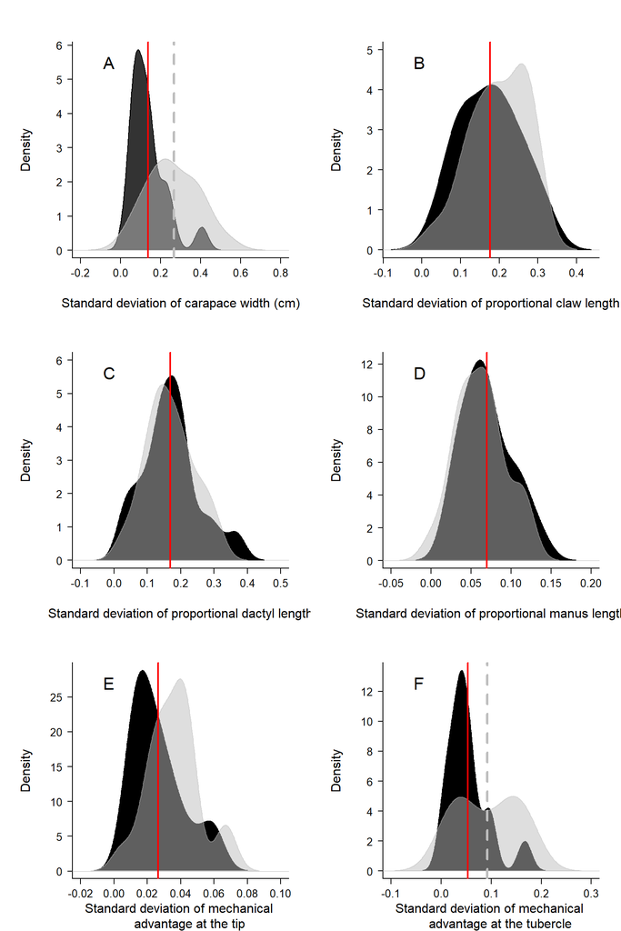

```r
par(bty = 'l', mfrow = c(3,2), cex.lab = 1.5, cex.axis = 1.3,
    mar = c(5.1,7.1,4.1,2.1), mgp = c(4,1,0))

plot(density(burrow.mean$sd.carapace, na.rm = T),
     main = "", las = 1, bty = 'l',
     xlab = "Standard deviation of carapace width (cm)",
     xlim = c(-0.2, 0.8))
polygon( density(burrow.mean$sd.carapace, na.rm = T), col = alpha( "black", 0.8), border = "black" )
polygon( density(surface.mean$sd.carapace, na.rm = T),
         col = alpha('grey', 0.5) , border = alpha('grey', 0.7) )
abline(v = coef(sd1_OUf)[1], col = 'red', lwd = 2)
abline(v = coef(sd1_OUf)[1] + coef(sd1_OUf)[2], col = 'grey', lwd = 3, lty = 2)
legend("topleft", legend = "A",bty = 'n', cex = 2)

plot(density(burrow.mean$sd.claw, na.rm = T),
     main = "", las = 1, bty = 'l',
     xlab = "Standard deviation of proportional claw length",
     ylim = c( 0, 5 ))
polygon( density(burrow.mean$sd.claw, na.rm = T), col = "black", border = 'black' )
polygon( density(surface.mean$sd.claw, na.rm = T),
         col = alpha('grey', 0.5) , border = alpha('grey', 0.5) )
abline(v = coef(sd2_OUf)[1], col = 'red', lwd = 2)
legend("topleft", legend = "B",bty = 'n', cex = 2)


plot(density(burrow.mean$sd.dactyl, na.rm = T),
     main = "", las = 1, bty = 'l',
     xlab = "Standard deviation of proportional dactyl length",
     ylim = c(0,6),
     xlim = c(-0.1,0.5))
polygon( density(burrow.mean$sd.dactyl, na.rm = T), col = "black", border = 'black' )
polygon( density(surface.mean$sd.dactyl, na.rm = T),
         col = alpha('grey', 0.5) , border = alpha('grey', 0.5) )
abline(v = coef(sd3_OUf)[1], col = 'red', lwd = 2)
legend("topleft", legend = "C",bty = 'n', cex = 2)

plot(density(burrow.mean$sd.manus, na.rm = T),
     main = "", las = 1, bty = 'l',
     xlab = "Standard deviation of proportional manus length",
     xlim = c(-0.05,0.2))
polygon( density(burrow.mean$sd.manus, na.rm = T) , col = "black", border = 'black' )
polygon( density(surface.mean$sd.manus, na.rm = T) ,
         col = alpha('grey', 0.5) , border = alpha('grey', 0.5) )
abline( v = coef( sd4_OUf )[1] , col = 'red' , lwd = 2)
legend("topleft", legend = "D",bty = 'n', cex = 2)

plot(density(burrow.mean$sd.tip, na.rm = T),
     main = "", las = 1, bty = 'l',
     xlab = "Standard deviation of mechanical
     advantage at the tip",
     xlim = c( -0.02, 0.1))
polygon( density(burrow.mean$sd.tip, na.rm = T), col = "black", border = 'black' )
polygon( density(surface.mean$sd.tip, na.rm = T),
         col = alpha('grey', 0.5) , border = alpha('grey', 0.5) )
abline( v = coef(sd5_OUf)[1] , col = 'red' , lwd = 2)
legend("topleft", legend = "E",bty = 'n', cex = 2)


plot(density(burrow.mean$sd.tub, na.rm = T),
     main = "", las = 1, bty = 'l',
     xlab = "Standard deviation of mechanical
     advantage at the tubercle",
     xlim = c(-0.1, 0.3) )
polygon( density(burrow.mean$sd.tub, na.rm = T), col = "black", border = 'black' )
polygon( density(surface.mean$sd.tub, na.rm = T),
         col = alpha('grey', 0.5) , border = alpha('grey', 0.5) )

abline(v = coef(sd6_OUf)[1], col = 'red', lwd = 2)
abline(v = coef(sd6_OUf)[1] + coef(sd6_OUf)[2], col = 'grey', lwd = 3, lty = 2)
legend("topleft", legend = "F",bty = 'n', cex = 2)
```

## Ancestral state reconstruction

We calculated the ancestral state of both the mating system and proportional claw length. For the mating system, we ran the “Equal rates” model and the “All rates differ” model and compared the best fitted model using AIC. For the continuous variable (proportional claw length), we also used ace() but simulated trait evolution using a Brownian motion model of evolution for each. However, to improve the amount of information in our tests, we performed the ancestral state reconstructions with all the species in the phylogeny. For the species we could not determine the mating system, we calculated the probability of them being in each state using the “make.simmap()” function of the phytools package. Further, these are simply visual aids and not tests. Thus, we did not perform any comparison between different evolutionary models for the continuous variable.

```r
#### ANC RECON #####

uca.full = read.csv("D:/OneDrive/Orientados/Mestrado - Jonatas/Mestrado/new_paper/claw.evol/data/medidas_full.csv" , h = T, sep = ';')

uca.mate.full = read.csv("D:/OneDrive/Orientados/Mestrado - Jonatas/Mestrado/new_paper/claw.evol/data/mating_short_all_spp.csv", h = T, sep = ';')

phy2 = read.nexus("D:/OneDrive/Orientados/Mestrado - Jonatas/Mestrado/new_paper/claw.evol/data/combined_50_burn_MCC_3.nex")

uca.mate.full = uca.mate.full %>% arrange (sp)

rownames(uca.mate.full) = uca.mate.full$sp

uca.sim = uca.mate.full[,-c(1)]

sim_ard = make.simmap(tree = phy2, x = as.matrix(uca.sim), model = "ARD", nsim = 1000)
```

```
## make.simmap is sampling character histories conditioned on
## the transition matrix
##
## Q =
##              burrow     surface
## burrow  -0.01208308  0.01208308
## surface  0.02178413 -0.02178413
## (estimated using likelihood);
## and (mean) root node prior probabilities
## pi =
##  burrow surface
##     0.5     0.5
```

```
## Done.
```

```r
sim_er = make.simmap(tree = phy2, x = as.matrix(uca.sim), model = "ER", nsim = 1000)
```

```
## make.simmap is sampling character histories conditioned on
## the transition matrix
##
## Q =
##              burrow     surface
## burrow  -0.01745233  0.01745233
## surface  0.01745233 -0.01745233
## (estimated using likelihood);
## and (mean) root node prior probabilities
## pi =
##  burrow surface
##     0.5     0.5
```

```
## Done.
```

```r
### Model comparison

AIC.er = (-2 * sim_er[[1]]$logL) + (2 * 1)

AIC.ard = (-2 * sim_ard[[1]]$logL) + (2 * 2)

AIC.er
```

```
## [1] 55.04393
## attr(,"df")
## [1] 1
```

```r
AIC.ard
```

```
## [1] 56.46326
## attr(,"df")
## [1] 2
```

```r
AIC.er - AIC.ard
```

```
## [1] -1.41933
## attr(,"df")
## [1] 1
```

```r
### The ER model either had the lowest AIC.

## Check the results

sum_sim = describe.simmap(sim_er)

## We now run ace for continuous variables. It does this by running a BM model of evolution on our data. We will run this on the claw to carapace ratio and the mechanical advantage.


uca.short2 = uca.full %>% group_by(sp) %>%
  summarise(
    mean.carapace = mean( carapace, na.rm = T),
    mean.claw = mean( claw_size, na.rm=T)
  )

uca.short2 = as.data.frame(uca.short2)

rownames(uca.short2) = uca.short2$sp

name.check(phy, uca.short2)
```

```
## $tree_not_data
## character(0)
##
## $data_not_tree
## [1] "Afruca_tangeri"       "Austruca_bengali"     "Austruca_mjoebergi"
## [4] "Austruca_perplexa"    "Leptuca_thayeri"      "Leptuca_uruguayensis"
## [7] "Uca_stylifera"
```

```r
uca.short2$claw.ratio = uca.short2$mean.claw/uca.short2$mean.carapace
uca.short2$claw.ratio
```

```
##  [1] 1.666756 1.383590 1.440833 1.743615 1.582675 1.895385 1.158320 1.487853
##  [9] 1.301651 1.767891 1.332327 1.457632 1.510253 1.463845 1.502608 1.021622
## [17] 1.736098 1.495807 1.482557 1.309360 1.584800 1.608693 1.680731 1.573037
## [25] 1.663460 1.816667 1.642364 1.249551 1.628463 1.172031 1.477839 1.419034
## [33] 1.488339 1.351342 1.332737 1.380877 1.509091 1.597098 1.535012 1.563705
## [41] 1.378798 1.673576 1.564735 1.366528 1.534015 1.360976 1.108046 1.415089
## [49] 1.590708
```

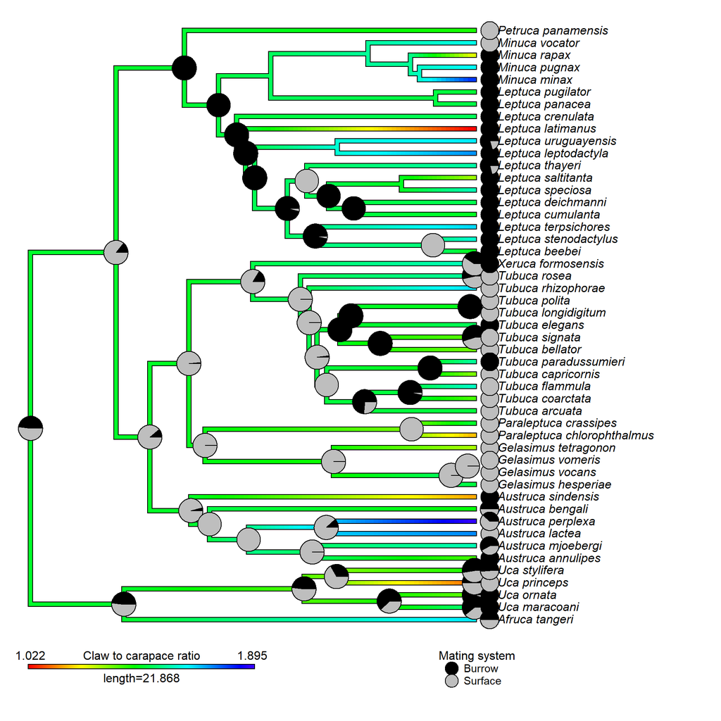

```r
claw.r = setNames(uca.short2$claw.ratio, rownames(uca.short2))

contC = contMap(phy2, claw.r, plot=FALSE)

ace.ratio = ace(claw.r, phy2, type="continuous")


### Preparing for plotting

ace_for_plot = sum_sim$ace[-c(45:90),]

col = viridis(200,alpha=1,option="D",direction=-1)
cols = setNames(c("black","grey"), c("burrow", "surface"))

## Now, plotting both trees combined. We merged them on photoshop later.

plot(contC, lwd=5, ftype="i", xlim=c(0,65), leg.txt='Claw to carapace ratio', res = 300,
     offset = 1.6)

nodelabels(node = 1:phy2$Nnode+Ntip(phy), pie = ace_for_plot, # ACE do mating
           piecol = cols, cex= .85)

tiplabels(pie = sum_sim$tips, offset = 1.5,
          piecol = cols, cex=0.65)


text("Mating system",x=44,y=-1,cex=1,font=1, pos=1)
text(c('Burrow','Surface'), x=42,y=c(-3,-4),cex=.9,font=1,pos=4)
points(x=41.5,y=-3,pch=21,bg='black',cex=2.5)
points(x=41.5,y=-4,pch=21,cex=2.5, bg = 'grey')
```

One additional test and plot regarding the proportional claw length. Does the mating system influence proportional claw length?

```r
uca.short$prop.claw = uca.short$mean.claw / uca.short$mean.carapace


prop_BM = readRDS("D:/OneDrive/Orientados/Mestrado - Jonatas/Mestrado/new_paper/claw.evol/data/prop_BM.rds")
prop_OUf = readRDS("D:/OneDrive/Orientados/Mestrado - Jonatas/Mestrado/new_paper/claw.evol/data/prop_OUf.rds")
prop_OUr = readRDS("D:/OneDrive/Orientados/Mestrado - Jonatas/Mestrado/new_paper/claw.evol/data/prop_OUr.rds")

### These are the models
#prop_BM = phylolm(prop.claw ~ mating, data = uca.short, phy = phy, model = "BM",
#                  measurement_error = T, boot = 1000)
#prop_OUf = phylolm(prop.claw ~ mating, data = uca.short, phy = phy, model = "OUfixedRoot",
#                  upper.bound = 300, measurement_error = T, boot = 1000)
#prop_OUr = phylolm(prop.claw ~ mating, data = uca.short, phy = phy, model = "OUrandomRoot",
#                  upper.bound = 300, measurement_error = T, boot = 1000)
###


compare_performance(prop_BM, prop_OUf, prop_OUr)
```

```
## Some of the nested models seem to be identical
```

```
## # Comparison of Model Performance Indices
##
## Name     |   Model | AIC (weights) | BIC (weights) |    R2 | R2 (adj.) |  RMSE | Sigma
## --------------------------------------------------------------------------------------
## prop_BM  | phylolm | -17.2 (0.576) | -10.2 (0.764) | 0.009 |    -0.015 | 0.179 | 0.189
## prop_OUf | phylolm | -15.2 (0.212) |  -6.5 (0.118) | 0.009 |    -0.015 | 0.179 | 0.191
## prop_OUr | phylolm | -15.2 (0.212) |  -6.5 (0.118) | 0.009 |    -0.015 | 0.179 | 0.191
```

```r
summary(prop_BM)
```

```
##
## Call:
## phylolm(formula = prop.claw ~ mating, data = uca.short, phy = phy,
##     model = "BM", measurement_error = T, boot = 1000)
##
##    AIC logLik
## -17.15  12.58
##
## Raw residuals:
##      Min       1Q   Median       3Q      Max
## -0.47020 -0.10755  0.01403  0.11462  0.32485
##
## Mean tip height: 43.73622
## Parameter estimate(s) using ML:
## sigma2: 1.605819e-12
## sigma2_error: 0.03217095
##
## Coefficients:
##                Estimate    StdErr   t.value lowerbootCI upperbootCI p.value
## (Intercept)    1.491821  0.039185 38.071632    1.419748      1.5681  <2e-16 ***
## matingsurface -0.034955  0.056784 -0.615577   -0.139570      0.0723  0.5417
## ---
## Signif. codes:  0 '***' 0.001 '**' 0.01 '*' 0.05 '.' 0.1 ' ' 1
##
## R-squared: 0.009384  Adjusted R-squared: -0.01538
##
## sigma2: 1.605819e-12
##       bootstrap mean: 1.52868e-12 (on raw scale)
##                       1.49075e-12 (on log scale, then back transformed)
##       bootstrap 95% CI: (9.239499e-13,2.293999e-12)
##
## sigma2_error: 0.03217095
##       bootstrap mean: 0.03062555 (on raw scale)
##                       0.02986565 (on log scale, then back transformed)
##       bootstrap 95% CI: (0.0185104,0.04595794)
##
## Parametric bootstrap results based on 1000 fitted replicates
```

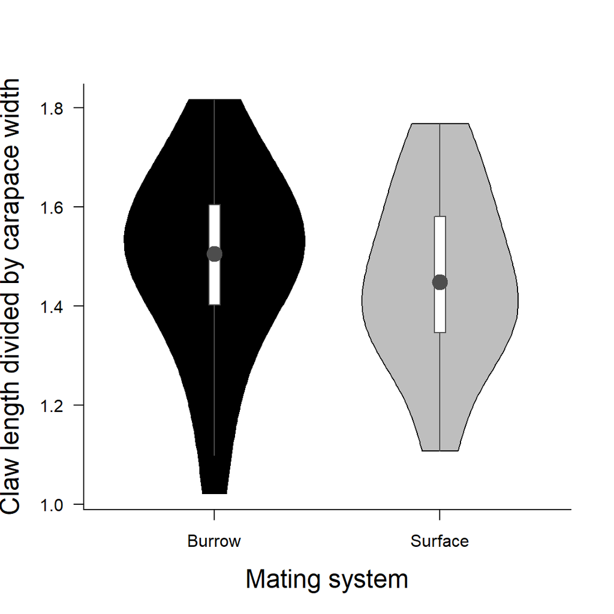

```r
par(bty = 'l',  cex.lab = 1.5, cex.axis = 1.3)
vioplot(prop.claw ~ as.factor(mating), data = uca.short,
        las = 1,  names = c("Burrow", "Surface"),
        ylab = "Claw length divided by carapace width",
        xlab = 'Mating system',
        col = c('black', 'grey'),
        rectCol = 'white', lineCol = 'grey30',
        colMed = 'grey30', cex = 2,
        areaEqual = T)
```

## Ratematrix

We used the ratematrix package to calculate the rates of evolution of claw traits in each mating systems. The package also calculated the evolutionary covariance and evolutionary correlation of the traits in each mating system. After all of this was calculated, we used the functions implemented in Slater & Friscia (2019) to test if the evolutionary covariation of the traits differed in each mating system. We performed three analyses: one for claw evolutionary allometry, another for the claw lever and muscle, and another for claw mechanical advantage and relative manus length (the same models we ran PGLS regressions for).

For all models, we used a custom flat prior that encompassed the distribution of our data.

### CLAW MANUS AND DACTYL

```r
#### PREPARING THE DATA FOR RATEMATRIX ####

mat = setNames(uca.short$mating, rownames(uca.short))

resp.data = uca.short[c("prop.out2","prop.manus")]

resp.scale = scale(resp.data,scale = F)

colsb = setNames(c("black","gray"),levels(as.factor(mat)))

phy.sim = make.simmap(phy, mat, model="ER")
```

```
## make.simmap is sampling character histories conditioned on
## the transition matrix
##
## Q =
##              burrow     surface
## burrow  -0.01745233  0.01745233
## surface  0.01745233 -0.01745233
## (estimated using likelihood);
## and (mean) root node prior probabilities
## pi =
##  burrow surface
##     0.5     0.5
```

```
## Done.
```

```r
class(phy.sim)
```

```
## [1] "simmap" "phylo"
```

```r
#### BUILDING A FLAT PRIOR ####

par.mu = rbind( c(-2,2), c(-2,2) )
par.sd = rbind( c(0,2), c(0,2) )
prior = makePrior(r=2, p=2, den.mu = "unif", par.mu = par.mu, den.sd = "unif", par.sd=par.sd)
sample.prior = samplePrior(n=1, prior = prior, sample.sd = T, rebuild.R = F)

# After building the prior, the next step is running the model to get the mcmc chain for the analyses
# We are running four independent chains, each with a different prior sampling. After we run each chain,
# we analyze the run, making sure it converged and run the next one.

##### MODELS - DO NOT RUN #####
### DO NOT RUN UNLESS YOU WANT NEW MCMC CHAINS ###
### THE MCMC CHAINS GENERATED ARE LOADED AFTER THIS PART ###

## First MCMC chain

#handle = ratematrixMCMC(data = resp.scale, phy = phy.sim, dir = '/result_mcmc',gen = 1e+07,
#                        v = 50, prior = prior, start = sample.prior
#)

#logAnalyzer(handle, burn = 0.3, thin = 1)

#mcmc = readMCMC(handle,burn = 0.3, thin = 1)

### Reading the mcmc chains to make sure everything is in order and the roots have been sampled appropriately

#plotRatematrix(mcmc, set.xlim = c(-0.02,0.3))
#plotRootValue(mcmc)

## Second MCMC chain

#sample.prior2 = samplePrior(n=1, prior = prior, sample.sd = T, rebuild.R = F)
#handle2 = ratematrixMCMC(data = resp.scale, phy = phy.sim, dir = '/result_mcmc',gen = 1e+07,
#                         v = 50, prior = prior, start = sample.prior2
#)

#logAnalyzer(handle2, burn = 0.3, thin = 1)

#mcmc2 = readMCMC(handle2,burn = 0.3, thin = 1)

#plotRatematrix(mcmc2)
#plotRootValue(mcmc2)


## Third MCMC chain

#sample.prior3 = samplePrior(n=1, prior = prior, sample.sd = T, rebuild.R = F)
#handle3 = ratematrixMCMC(data = resp.scale, phy = phy.sim, dir = '/result_mcmc',gen = 1e+07,
#                         v = 50,  prior = prior, start = sample.prior3
#)

#logAnalyzer(handle3, burn = 0.3, thin = 1)

#mcmc3 = readMCMC(handle3,burn = 0.3, thin = 1)

#plotRatematrix(mcmc3)
#plotRootValue(mcmc3)

## Fourth MCMC chain

#sample.prior4= samplePrior(n=1, prior = prior, sample.sd = T, rebuild.R = F)
#handle4 = ratematrixMCMC(data = resp.scale, phy = phy.sim, dir = '/result_mcmc',gen = 1e+07,
#                         v = 50, prior = prior, start = sample.prior4
#)

#logAnalyzer(handle4, burn = 0.3, thin = 1)
#
#mcmc4 = readMCMC(handle4,burn = 0.3, thin = 1)

#plotRatematrix(mcmc4)
#plotRootValue(mcmc4)

# Now, saving all mcmc chains in the same file so we don't have to run it every time.

#save(mcmc, mcmc2, mcmc3, mcmc4, file = "data/mcmc_dactyl.Rdata")

##### LOAD MCMC CHAINS GENERATED! ####

load(file = "D:/OneDrive/Orientados/Mestrado - Jonatas/Mestrado/new_paper/claw.evol/data/mcmc_dactyl.Rdata")


# Measuring the convergence of the four chains
Rfactor = checkConvergence(mcmc, mcmc2, mcmc3, mcmc4)
Rfactor
```

```
## $gelman
## $gelman$diag_root
## Potential scale reduction factors:
##
##            Point est. Upper C.I.
## prop.out2           1          1
## prop.manus          1          1
##
##
## $gelman$burrow
## Potential scale reduction factors:
##
##     Point est. Upper C.I.
## 1,1          1          1
## 1,2          1          1
## 2,1          1          1
## 2,2          1          1
##
##
## $gelman$surface
## Potential scale reduction factors:
##
##     Point est. Upper C.I.
## 1,1          1          1
## 1,2          1          1
## 2,1          1          1
## 2,2          1          1
##
##
##
## $ess
##           root   burrow  surface
## var1  5217.875 37276.29 28466.85
## var2 18373.920 22520.44 14192.05
## var3        NA 22520.44 14192.05
## var4        NA 37852.57 29823.51
```

```
## Plotting multiple regimes.
## Table with regimes and colors (names or HEX):
##  burrow surface
##   black    grey
```

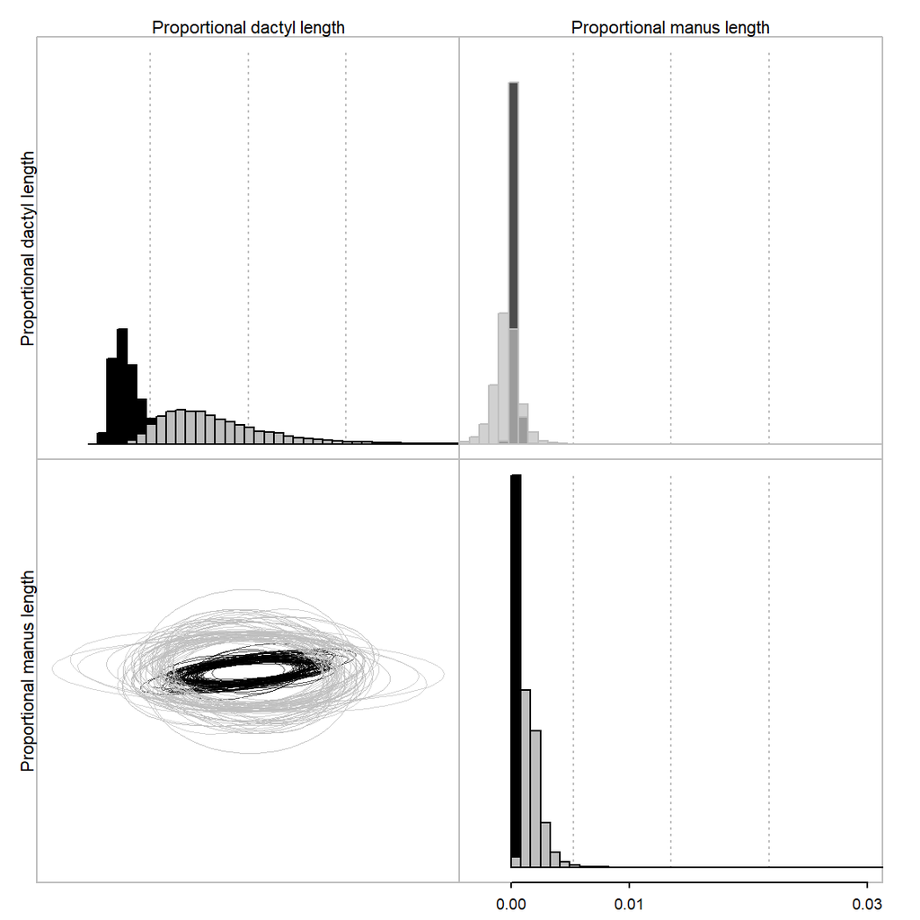

```r
# Merging them all in the same object
merged_mcmc = mergePosterior(mcmc, mcmc2, mcmc3, mcmc4)

# Plotting the results.

# grey = surface mating
# black = burrow mating

plotRatematrix(merged_mcmc, set.xlim = c(-0.003,0.03), alphaOff = 0.7, alphaEll = 0.7,
               colors=c("grey","black")[c(2,1)], n.lines = 100, point.wd = 1,
               set.leg = c("Proportional dactyl length", "Proportional manus length"))
```

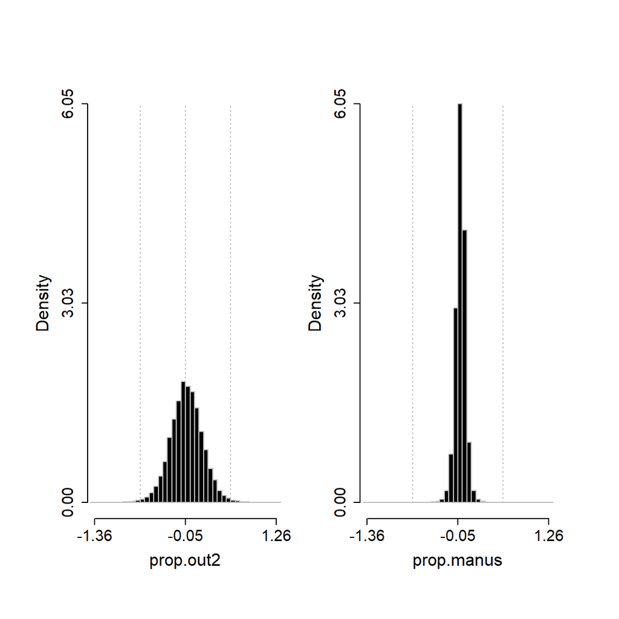

```r
# This graph requires some explaining. The plots on the main diagonal show the rate of evolution of one trait in each mating system. The spread on the surface mating (grey) suggests that there is more uncertainty on the estimation of the rate of evolution of that regime when compared to the burrow mating system. The plot on the off-diagonal (the one that is a little bit transparent) show the evolutionary covariance of the traits in each mating system. The ellipsis shows the 95% confidence interval of each bivariate distribution. The size, direction, and angle of the ellipsis shows how these two traits are covarying.

plotRootValue(merged_mcmc)
```

```r
# This second graph shows how the posterior distribution of the values retrieved from the root of the tree.


### Now, we test how much the two mating systems overlap with one another

# This first test shows the probability of overlap between the posterior distributions. With the small values denoting that there is very low probability of the two posteriors to overlap.
testRatematrix(chain = merged_mcmc, par = "all")
```

```
## [[1]]
## [[1]]$`Regime burrow x surface`
##            [,1]         [,2]
## [1,] 0.06260952 0.4852190476
## [2,] 0.48521905 0.0005809524
```

```r
# This test shows the overlap of the correlation between covariance matrices.
testRatematrix(chain = merged_mcmc, par = "correlation")
```

```
## [[1]]
## [[1]]$`Regime burrow x surface`
##      [,1]      [,2]
## [1,]   NA 0.1599905
## [2,]   NA        NA
```

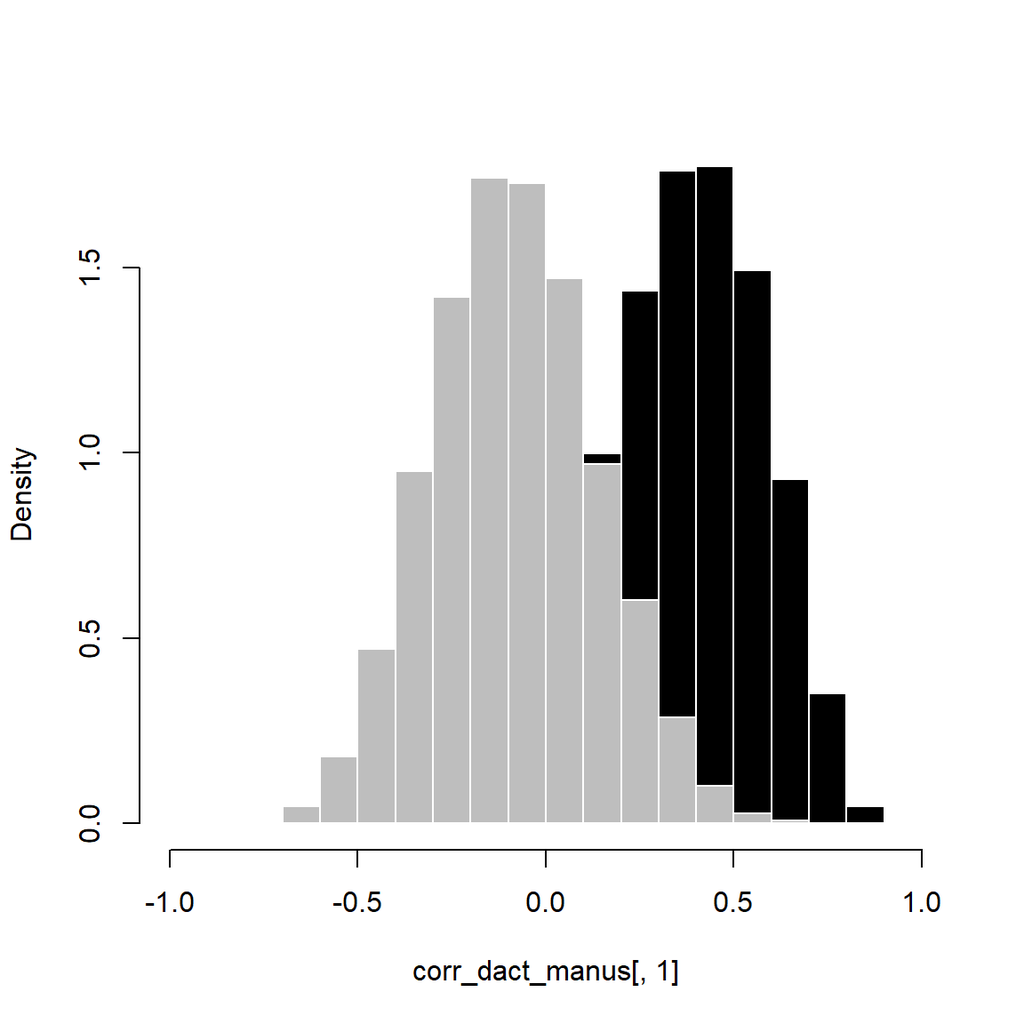

```r
# To know the correlations, we need to first extract these correlations and then plot them.

corr_dact_manus = extractCorrelation(merged_mcmc)

hist(x = corr_dact_manus[,1], xlim = c(-1,1), main = "", col = "black"
     , border = "white", breaks = 20, freq = FALSE)
hist(x = corr_dact_manus[,2], xlim = c(-1,1), main = "", col = "grey"
     , border = "white", breaks = 20, freq = FALSE,add=T)
```

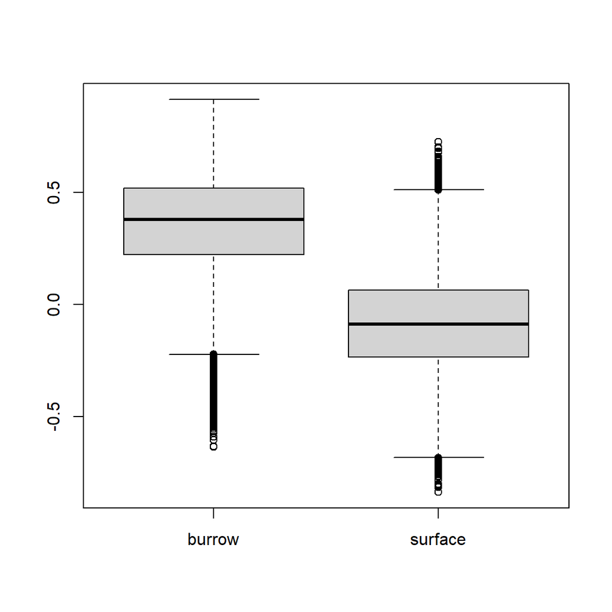

```r
boxplot(x = corr_dact_manus)
```

```r
## None of these, however, are formal statistical tests.
## That is why we use the same framework in Slater & Friscia (2019) to test if the covariance matrices differ between the mating systems. The analysis is based on Ovaskainen et al. (2008) work, but basically it calculates pairwise differences between the covariance matrices.
## Below, we provide the same results.

complete.dactyl.post <- merged_mcmc$matrix

### Ovaskainen Test ###
## If you remove the # from the code, it will save the results in a txt file

#zz <- file("D:/Dropbox/Orientados/Mestrado - Jonatas/Mestrado/new_paper/claw.evol/rsde/dactyl_OvaskainenTest_all.txt", open = "wt")
#sink(zz)
ovd.test <- pairwise.Ovaskainen(complete.dactyl.post)
```

```
## [1] "probability that matrices burrow and surface differ = 0"
```

```r
lapply(ovd.test, quantile, c(0.025, 0.5, 0.975))
```

```
## $distance_between_burrow_and_surface
##       2.5%        50%      97.5%
## -1.1247180 -0.7780971 -0.3744235
```

```r
#sink()
```

### CLAW LENGTH AND CARAPACE WIDTH

Now we will do the same as before, but for the evolutionary allometry

```r
#### PREPARING THE DATA FOR RATEMATRIX ####

mat = setNames(uca.short$mating, rownames(uca.short))

resp.data = uca.short[c("mean.claw","mean.carapace")]

resp.scale = scale(resp.data,scale = F)

colsb = setNames(c("black","gray"),levels(as.factor(mat)))

phy.sim = make.simmap(phy, mat, model="ER")
```

```
## make.simmap is sampling character histories conditioned on
## the transition matrix
##
## Q =
##              burrow     surface
## burrow  -0.01745233  0.01745233
## surface  0.01745233 -0.01745233
## (estimated using likelihood);
## and (mean) root node prior probabilities
## pi =
##  burrow surface
##     0.5     0.5
```

```
## Done.
```

```r
class(phy.sim)
```

```
## [1] "simmap" "phylo"
```

```r
#### BUILDING A FLAT PRIOR ####

par.mu <- rbind( c(-5,5), c(-5,5) )
par.sd <- rbind( c(0,3), c(0,3) )
prior <- makePrior(r=2, p=2, den.mu = "unif", par.mu = par.mu, den.sd = "unif", par.sd = par.sd)
sample.prior = samplePrior(n=1, prior = prior, sample.sd = T, rebuild.R = F)


##### MODELS - DO NOT RUN #####
### DO NOT RUN UNLESS YOU WANT NEW MCMC CHAINS ###
### THE MCMC CHAINS GENERATED ARE LOADED AFTER THIS PART ###

## First MCMC chain

#handle = ratematrixMCMC(data = resp.scale, phy = phy.sim, dir = '/result_mcmc',gen = 10000000,
#                        v = 50, prior = prior, start = sample.prior
#)

#logAnalyzer(handle, burn = 0.3, thin = 1)

#mcmc = readMCMC(handle,burn = 0.3, thin = 1)

#plotRatematrix(mcmc, set.xlim = c(-0.02,0.3))
#plotRootValue(mcmc)

## Second MCMC chain

#sample.prior2 = samplePrior(n=1, prior = prior, sample.sd = T, rebuild.R = F)
#handle2 = ratematrixMCMC(data = resp.scale, phy = phy.sim, dir = '/result_mcmc',gen = 10000000,
#                         v = 50, prior = prior, start = sample.prior2
#)

#logAnalyzer(handle2, burn = 0.3, thin = 1)

#mcmc2 = readMCMC(handle2,burn = 0.3, thin = 1)

#plotRatematrix(mcmc2)
#plotRootValue(mcmc2)

## Third MCMC chain

#sample.prior3 = samplePrior(n=1, prior = prior, sample.sd = T, rebuild.R = F)
#handle3 = ratematrixMCMC(data = resp.scale, phy = phy.sim, dir = '/result_mcmc',gen = 10000000,
#                         v = 50,  prior = prior, start = sample.prior3
#)

#logAnalyzer(handle3, burn = 0.3, thin = 1)

#mcmc3 = readMCMC(handle3,burn = 0.3, thin = 1)

#plotRatematrix(mcmc3)
#plotRootValue(mcmc3)

## Fourth MCMC chain

#sample.prior4= samplePrior(n=1, prior = prior, sample.sd = T, rebuild.R = F)
#handle4 = ratematrixMCMC(data = resp.scale, phy = phy.sim, dir = '/result_mcmc',gen = 10000000,
#                         v = 50, prior = prior, start = sample.prior4
#)

#logAnalyzer(handle4, burn = 0.3, thin = 1)

#mcmc4 = readMCMC(handle4,burn = 0.3, thin = 1)

#plotRatematrix(mcmc4)
#plotRootValue(mcmc4)

#save(mcmc, mcmc2, mcmc3, mcmc4, file = "data/mcmc_claw.Rdata")

##### LOAD MCMC CHAINS GENERATED! ####

load(file = "D:/OneDrive/Orientados/Mestrado - Jonatas/Mestrado/new_paper/claw.evol/data/mcmc_claw.Rdata")

# Measuring the convergence of the four chains
Rfactor = checkConvergence(mcmc, mcmc2, mcmc3, mcmc4)
Rfactor
```

```
## $gelman
## $gelman$diag_root
## Potential scale reduction factors:
##
##               Point est. Upper C.I.
## mean.claw           1.01       1.03
## mean.carapace       1.01       1.03
##
##
## $gelman$burrow
## Potential scale reduction factors:
##
##     Point est. Upper C.I.
## 1,1          1          1
## 1,2          1          1
## 2,1          1          1
## 2,2          1          1
##
##
## $gelman$surface
## Potential scale reduction factors:
##
##     Point est. Upper C.I.
## 1,1          1          1
## 1,2          1          1
## 2,1          1          1
## 2,2          1          1
##
##
##
## $ess
##          root    burrow  surface
## var1 370.0032  9338.322 8883.037
## var2 534.6966  8594.735 7929.090
## var3       NA  8594.735 7929.090
## var4       NA 11894.604 8748.670
```

```
## Plotting multiple regimes.
## Table with regimes and colors (names or HEX):
##  burrow surface
##   black    grey
```

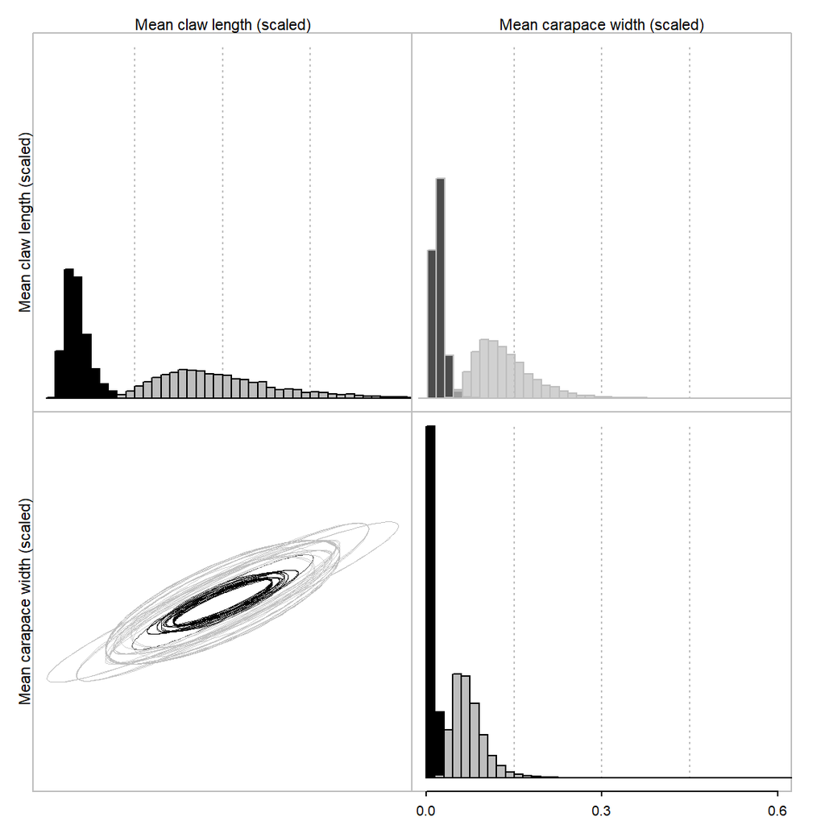

```r
# Merging them all in the same objetc
merged_mcmc = mergePosterior(mcmc, mcmc2, mcmc3, mcmc4)

# Plotting the results.

# grey = surface mating
# black = burrow mating

plotRatematrix(merged_mcmc, set.xlim = c(0,0.6), alphaOff = 0.7, alphaEll = 0.7,
               colors=c("grey","black")[c(2,1)], n.lines = 100, point.wd = 1,
               set.leg = c("Mean claw length (scaled)", "Mean carapace width (scaled)"))
```

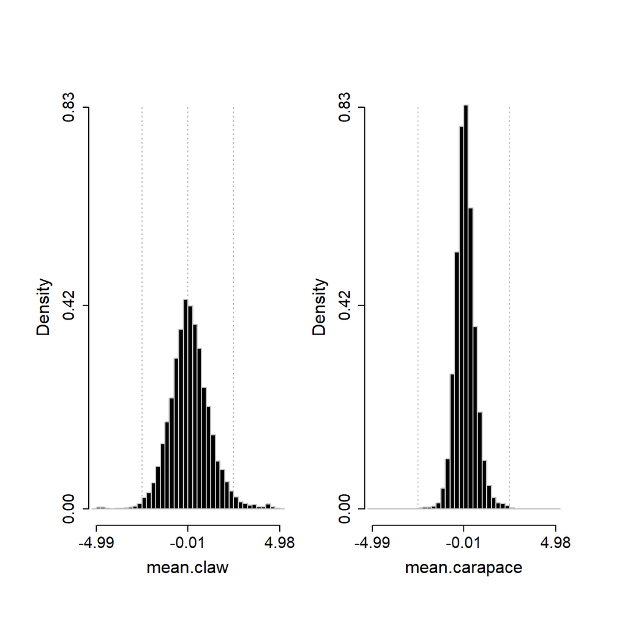

```r
# This graph requires some explaining. The plots on the main diagonal show the rate of evolution of one trait in each mating system. The spread on the surface mating (grey) suggests that there is more uncertainty on the estimation of the rate of evolution of that regime when compared to the burrow mating system. The plot on the off-diagonal (the one that is a little bit transparent) show the evolutionary covariance of the traits in each mating system. The ellipsis shows the 95% confidence interval of each bivariate distribution. The size, direction, and angle of the ellipsis shows how these two traits are covarying.

plotRootValue(merged_mcmc)
```

```r
# This second graph shows how the posterior distribution of the values retrieved from the root of the tree.

### Now, we test how much the two mating systems overlap with one another

# This first test shows the probability of overlap between the posterior distributions. With the small values denoting that there is very low probability of the two posteriors to overlap.
testRatematrix(chain = merged_mcmc, par = "all")
```

```
## [[1]]
## [[1]]$`Regime burrow x surface`
##             [,1]        [,2]
## [1,] 0.002380952 0.001914286
## [2,] 0.001914286 0.001152381
```

```r
# This test shows the overlap of the correlation between covariance matrices.
testRatematrix(chain = merged_mcmc, par = "correlation")
```

```
## [[1]]
## [[1]]$`Regime burrow x surface`
##      [,1]      [,2]
## [1,]   NA 0.7331048
## [2,]   NA        NA
```

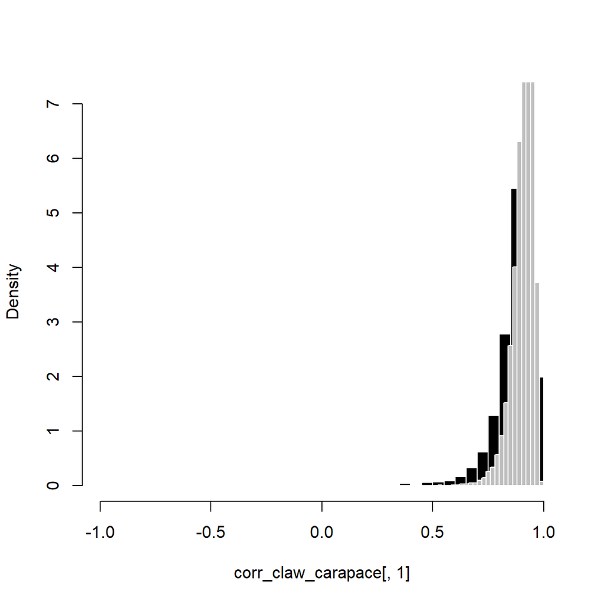

```r
# To know the correlations, we need to first extract these correlations and then plot them.

corr_claw_carapace = extractCorrelation(merged_mcmc)

hist(x = corr_claw_carapace[,1], xlim = c(-1,1), main = "", col = "black"
     , border = "white", breaks = 20, freq = FALSE)
hist(x = corr_claw_carapace[,2], xlim = c(-1,1), main = "", col = "grey"
     , border = "white", breaks = 20, freq = FALSE,add=T)
```

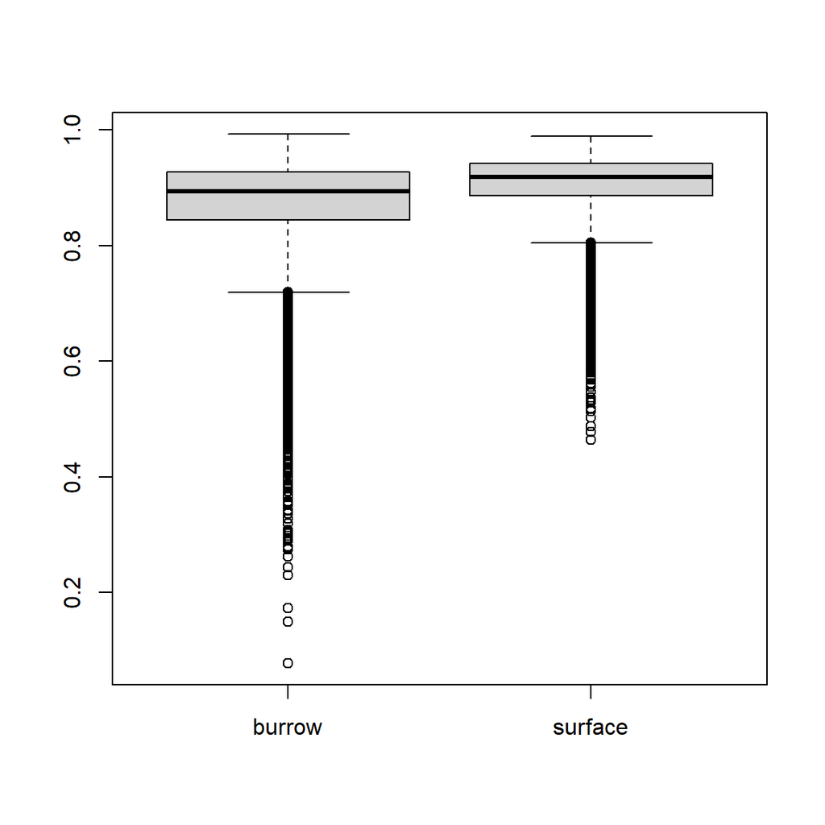

```r
boxplot(x = corr_claw_carapace)
```

```r
## None of these, however, are formal statistical tests.
## That is why we use the same framework in Slater & Friscia (2019) to test if the covariance matrices differ between the mating systems. The analysis is based on Ovaskainen et al. (2008) work, but basically it calculates pairwise differences between the covariance matrices.
## Below, we provide the same results.

complete.claw.post <- merged_mcmc$matrix

### Ovaskainen Test ###
## If you remove the # from the code, it will save the results in a txt file

#zz <- file("D:/Dropbox/Orientados/Mestrado - Jonatas/Mestrado/new_paper/claw.evol/rsde/claw_OvaskainenTest_all.txt", open = "wt")
#sink(zz)
ovd.test <- pairwise.Ovaskainen(complete.claw.post)
```

```
## [1] "probability that matrices burrow and surface differ = 0"
```

```r
lapply(ovd.test, quantile, c(0.025, 0.5, 0.975))
```

```
## $distance_between_burrow_and_surface
##       2.5%        50%      97.5%
## -1.0877244 -0.7051409 -0.2970116
```

```r
#sink()
```

### MECHANICAL ADVANTAGE AND RELATIVE MANUS LENGTH

```r
#### PREPARING THE DATA FOR RATEMATRIX ####

mat = setNames(uca.short$mating, rownames(uca.short))

resp.data = uca.short[c("mean.tip","prop.manus")]

resp.scale = scale(resp.data,scale = F)

colsb = setNames(c("black","gray"),levels(as.factor(mat)))

phy.sim = make.simmap(phy, mat, model="ER")
```

```
## make.simmap is sampling character histories conditioned on
## the transition matrix
##
## Q =
##              burrow     surface
## burrow  -0.01745233  0.01745233
## surface  0.01745233 -0.01745233
## (estimated using likelihood);
## and (mean) root node prior probabilities
## pi =
##  burrow surface
##     0.5     0.5
```

```
## Done.
```

```r
class(phy.sim)
```

```
## [1] "simmap" "phylo"
```

```r
#### BUILDING A FLAT PRIOR ####

par.mu = rbind( c(-1.5,1.5), c(-1.5,1.5) )
par.sd = rbind( c(0,1), c(0,1) )
prior = makePrior(r=2, p=2, den.mu = "unif", par.mu=par.mu,den.sd = "unif", par.sd=par.sd)
sample.prior = samplePrior(n=1, prior = prior, sample.sd = T, rebuild.R = F)


##### MODELS - DO NOT RUN #####
### DO NOT RUN UNLESS YOU WANT NEW MCMC CHAINS ###
### THE MCMC CHAINS GENERATED ARE LOADED AFTER THIS PART ###

## First MCMC chain

#handle = ratematrixMCMC(data = resp.scale, phy = phy.sim, dir = '/result_mcmc',gen = 1e+07,
#                        v = 50, prior = prior, start = sample.prior
#)

#logAnalyzer(handle, burn = 0.3, thin = 1)

#mcmc = readMCMC(handle,burn = 0.3, thin = 1)

#plotRatematrix(mcmc)
#plotRootValue(mcmc)

## Second MCMC chain

#sample.prior2 = samplePrior(n=1, prior = prior, sample.sd = T, rebuild.R = F)
#handle2 = ratematrixMCMC(data = resp.scale, phy = phy.sim, dir = '/result_mcmc',gen = 1e+07,
#                         v = 50, prior = prior, start = sample.prior2
#)

#logAnalyzer(handle2, burn = 0.3, thin = 1)

#mcmc2 = readMCMC(handle2,burn = 0.3, thin = 1)

#plotRatematrix(mcmc2)
#plotRootValue(mcmc2)

## Third MCMC chain

#sample.prior3 = samplePrior(n=1, prior = prior, sample.sd = T, rebuild.R = F)
#handle3 = ratematrixMCMC(data = resp.scale, phy = phy.sim, dir = '/result_mcmc',gen = 1e+07,
#                         v = 50,  prior = prior, start = sample.prior3
#)

#logAnalyzer(handle3, burn = 0.3, thin = 1)

#mcmc3 = readMCMC(handle3,burn = 0.3, thin = 1)

#plotRatematrix(mcmc3)
#plotRootValue(mcmc3)

## Fourth MCMC chain

#sample.prior4= samplePrior(n=1, prior = prior, sample.sd = T, rebuild.R = F)
#handle4 = ratematrixMCMC(data = resp.scale, phy = phy.sim, dir = '/result_mcmc',gen = 1e+07,
#                         v = 50, prior = prior, start = sample.prior4
#)

#logAnalyzer(handle4, burn = 0.3, thin = 1)

#mcmc4 = readMCMC(handle4,burn = 0.3, thin = 1)

#plotRatematrix(mcmc4)
#plotRootValue(mcmc4)

#save(mcmc, mcmc2, mcmc3, mcmc4, file = "data/mcmc_ratio.Rdata")

##### LOAD MCMC CHAINS GENERATED! ####

load(file = "D:/OneDrive/Orientados/Mestrado - Jonatas/Mestrado/new_paper/claw.evol/data/mcmc_ratio.Rdata")

# Measuring the convergence of the four chains
Rfactor = checkConvergence(mcmc, mcmc2, mcmc3, mcmc4)
Rfactor
```

```
## $gelman
## $gelman$diag_root
## Potential scale reduction factors:
##
##            Point est. Upper C.I.
## mean.tip            1          1
## prop.manus          1          1
##
##
## $gelman$burrow
## Potential scale reduction factors:
##
##     Point est. Upper C.I.
## 1,1          1          1
## 1,2          1          1
## 2,1          1          1
## 2,2          1          1
##
##
## $gelman$surface
## Potential scale reduction factors:
##
##     Point est. Upper C.I.
## 1,1          1          1
## 1,2          1          1
## 2,1          1          1
## 2,2          1          1
##
##
##
## $ess
##          root   burrow  surface
## var1 13801.66 48265.53 37438.41
## var2 12479.20 18282.13 18360.65
## var3       NA 18282.13 18360.65
## var4       NA 33432.96 32370.39
```

```
## Plotting multiple regimes.
## Table with regimes and colors (names or HEX):
##  burrow surface
##   black    grey
```

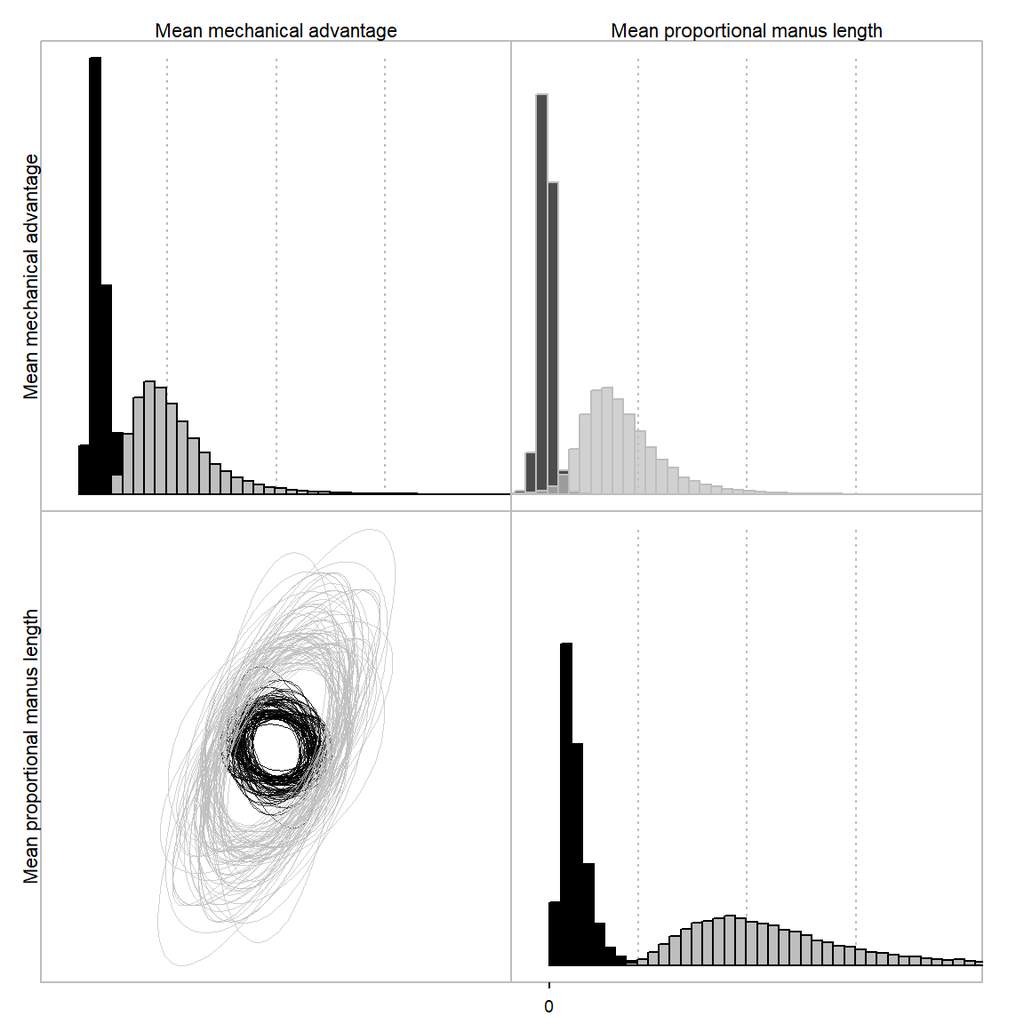

```r
# Merging them all in the same objetc
merged_mcmc = mergePosterior(mcmc, mcmc2, mcmc3, mcmc4)

# Plotting the results.

# grey = surface mating
# black = burrow mating

plotRatematrix(merged_mcmc, set.xlim = c(-0.00015,0.003), alphaOff = 0.7, alphaEll = 0.7,
               colors=c("grey","black")[c(2,1)], n.lines = 100, point.wd = 1,
               set.leg = c("Mean mechanical advantage", "Mean proportional manus length"))
```

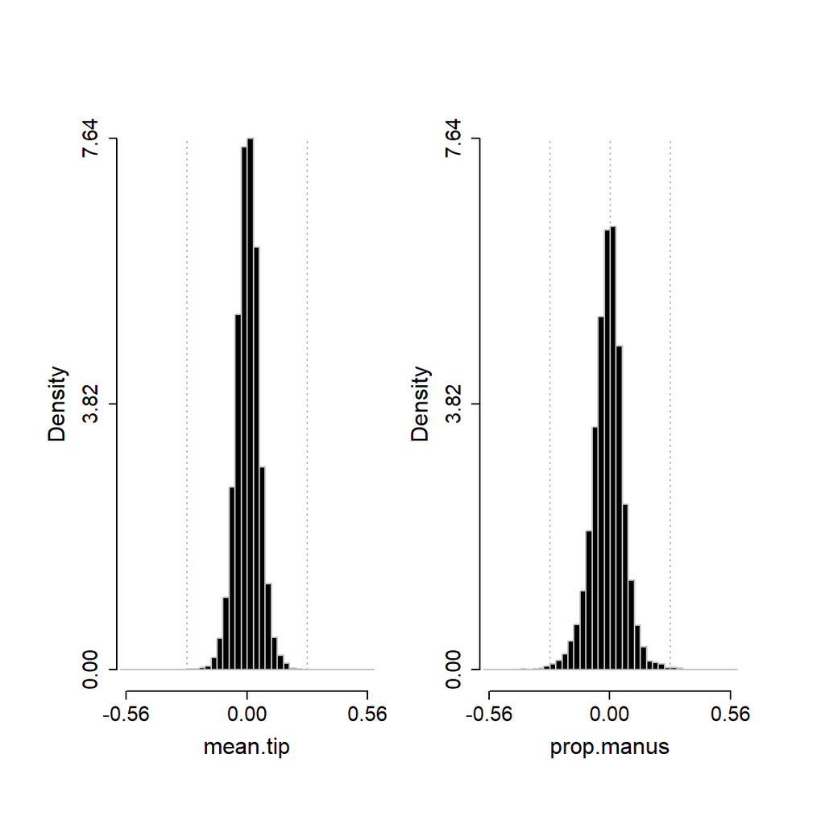

```r
# This graph requires some explaining. The plots on the main diagonal show the rate of evolution of one trait in each mating system. The spread on the surface mating (grey) suggests that there is more uncertainty on the estimation of the rate of evolution of that regime when compared to the burrow mating system. The plot on the off-diagonal (the one that is a little bit transparent) show the evolutionary covariance of the traits in each mating system. The ellipsis shows the 95% confidence interval of each bivariate distribution. The size, direction, and angle of the ellipsis shows how these two traits are covarying.

plotRootValue(merged_mcmc)
```

```r
# This second graph shows how the posterior distribution of the values retrieved from the root of the tree.

### Now, we test how much the two mating systems overlap with one another

# This first test shows the probability of overlap between the posterior distributions. With the small values denoting that there is very low probability of the two posteriors to overlap.
testRatematrix(chain = merged_mcmc, par = "all")
```

```
## [[1]]
## [[1]]$`Regime burrow x surface`
##            [,1]        [,2]
## [1,] 0.01466667 0.017066667
## [2,] 0.01706667 0.001085714
```

```r
# This test shows the overlap of the correlation between covariance matrices.
testRatematrix(chain = merged_mcmc, par = "correlation")
```

```
## [[1]]
## [[1]]$`Regime burrow x surface`
##      [,1]       [,2]
## [1,]   NA 0.04299048
## [2,]   NA         NA
```

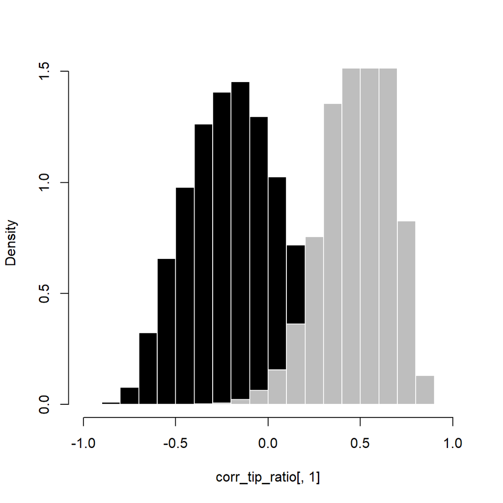

```r
# To know the correlations, we need to first extract these correlations and then plot them.

corr_tip_ratio = extractCorrelation(merged_mcmc)

hist(x = corr_tip_ratio[,1], xlim = c(-1,1), main = "", col = "black"
     , border = "white", breaks = 20, freq = FALSE)
hist(x = corr_tip_ratio[,2], xlim = c(-1,1), main = "", col = "grey"
     , border = "white", breaks = 20, freq = FALSE,add=T)
```

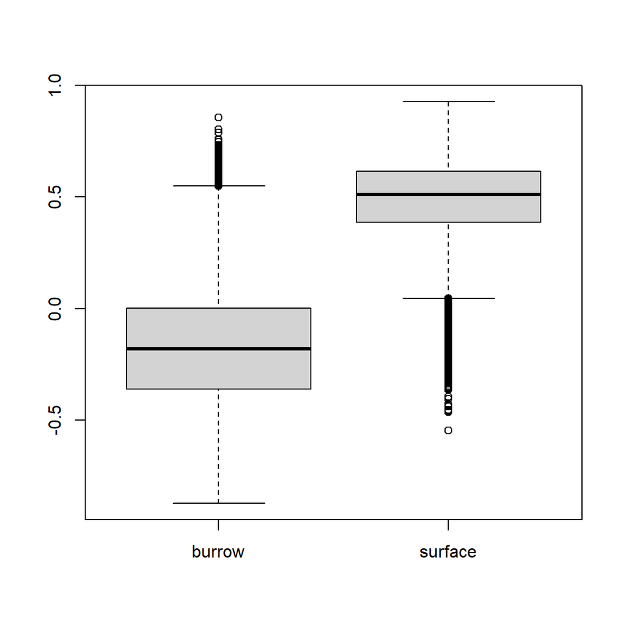

```r
boxplot(x = corr_tip_ratio)
```

```r
## None of these, however, are formal statistical tests.
## That is why we use the same framework in Slater & Friscia (2019) to test if the covariance matrices differ between the mating systems. The analysis is based on Ovaskainen et al. (2008) work, but basically it calculates pairwise differences between the covariance matrices.
## Below, we provide the same results.

complete.ratio.post <- merged_mcmc$matrix

### Ovaskainen Test ###
## If you remove the # from the code, it will save the results in a txt file

#zz <- file("D:/Dropbox/Orientados/Mestrado - Jonatas/Mestrado/new_paper/claw.evol/rsde/ratio_OvaskainenTest_all.txt", open = "wt")
#sink(zz)
ovd.test = pairwise.Ovaskainen(complete.ratio.post)
```

```
## [1] "probability that matrices burrow and surface differ = 0"
```

```r
lapply(ovd.test, quantile, c(0.025, 0.5, 0.975))
```

```
## $distance_between_burrow_and_surface
##       2.5%        50%      97.5%
## -1.1328152 -0.7524814 -0.2978050
```

```r
#sink()
```

### EVOLUTIONARY CORRELATION GRAPHS

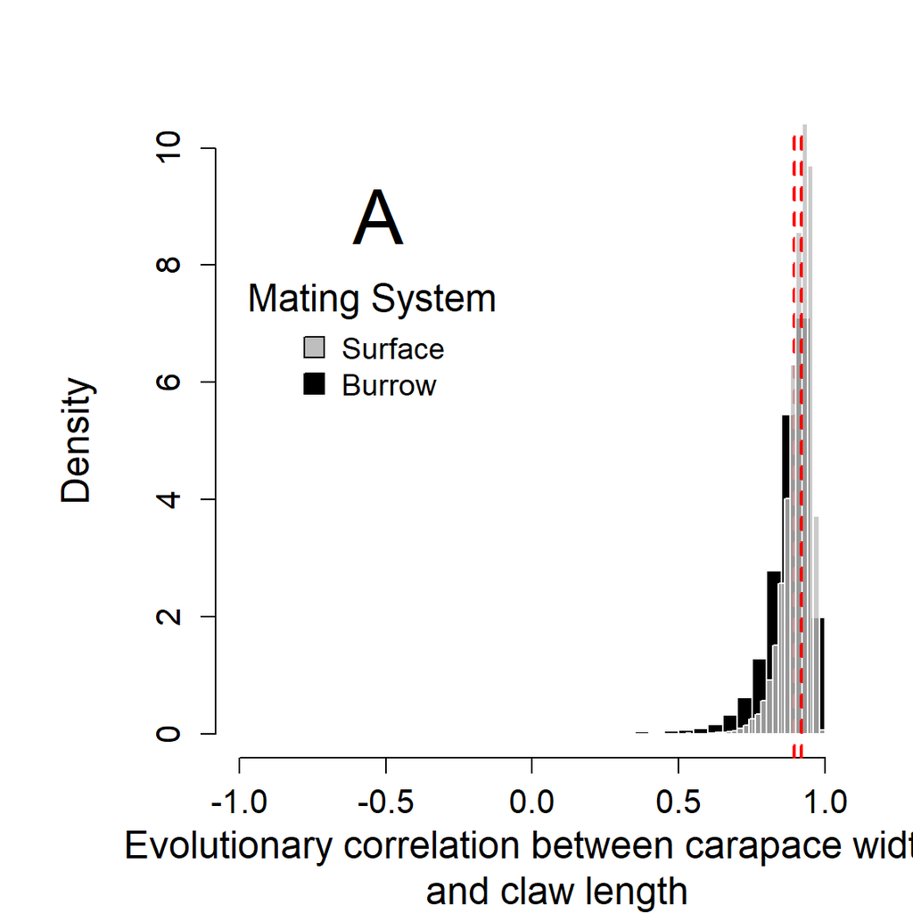

```r
par(bty = 'l', cex.lab = 1.5, cex.axis = 1.3,
    mar = c(5.1,7.1,4.1,2.1), mgp = c(4,1,0))


hist(x = corr_claw_carapace[,1], xlim = c(-1,1), main = "", col = "black"
     , border = "white", breaks = 20, freq = FALSE,
     ylim = c(0,10),
     xlab = "Evolutionary correlation between carapace width
     and claw length"
     )
abline( v = median(corr_claw_carapace[,1]), lwd = 2, col = 'red', lty = 2)

hist(x = corr_claw_carapace[,2], xlim = c(-1,1), main = "", col = alpha("grey", 0.8)
     , border = "white", breaks = 20, freq = FALSE,add=T)
abline( v = median(corr_claw_carapace[,2]), lwd = 2, col = 'red', lty = 2)

legend(x = -1, y = 8,
       legend = c("Surface", "Burrow"),
       pt.bg = c("grey", "black"),
       pch = 22,
       bty = "n",
       pt.cex = 2,
       title = "Mating System",
       title.cex = 1.5,
       cex = 1.2)
legend("topleft", legend = "A", bty = 'n', cex = 3)
```

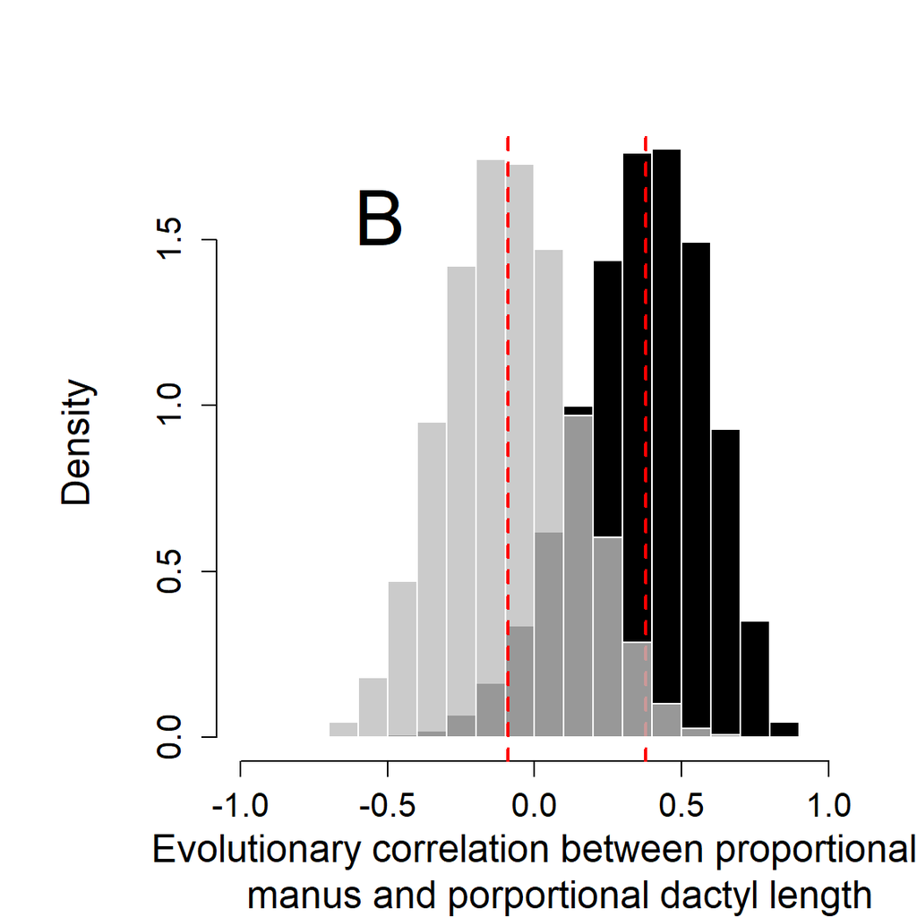

```r
hist(x = corr_dact_manus[,1], xlim = c(-1,1), main = "", col = alpha("black", 1),
     border = "white", breaks = 20, freq = FALSE,
     xlab = "Evolutionary correlation between proportional
     manus and porportional dactyl length")
abline( v = median(corr_dact_manus[,1]), lwd = 2, col = 'red', lty = 2)

hist(x = corr_dact_manus[,2], xlim = c(-1,1), main = "", col = alpha("grey",0.8)
     , border = "white", breaks = 20, freq = FALSE,add=T)
abline( v = median(corr_dact_manus[,2]), lwd = 2, col = 'red', lty = 2)

legend( "topleft", legend = "B", bty = 'n', cex = 3)
```

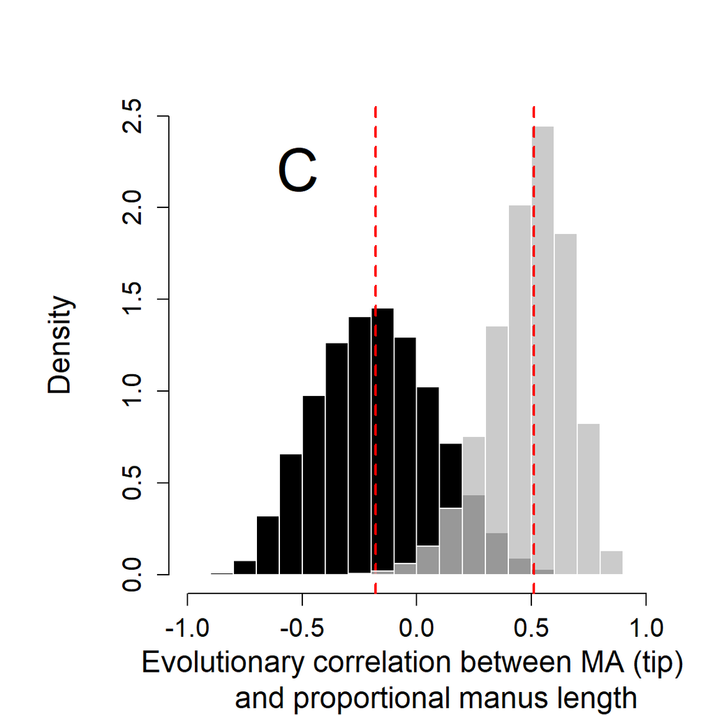

```r
hist(x = corr_tip_ratio[,1], main = "", col = "black"
     , border = "white", breaks = 20, freq = FALSE,
     xlim = c(-1,1), ylim = c(0,2.5),
     xlab = "Evolutionary correlation between MA (tip)
     and proportional manus length")
abline( v = median(corr_tip_ratio[,1]), lwd = 2, col = 'red', lty = 2)

hist(x = corr_tip_ratio[,2], main = "", col = alpha("grey", 0.8)
     , border = "white", breaks = 20, freq = FALSE,add=T)
abline( v = median(corr_tip_ratio[,2]), lwd = 2, col = 'red', lty = 2)


legend("topleft", legend = "C", bty = 'n', cex = 3)
```